# Predicting Developer Job Satisfaction: A Multi-Model Classification Study

Group W11G03

### 1 Problem Framing & Research Question

#### 1.1 Task Definition

In this project, we build the job satisfaction of developers into a supervised multi-classified task. The original JobSat variable is a self-scoring number of 0 to 10 points, but we convert it into a satisfaction group instead of predicting the exact score (Agresti, 2018). The model uses survey variables on the developer’s background, working conditions, technical practises and attitudes towards artificial intelligence tools. Therefore, the main goal is to test whether these characteristics can distinguish developers with different job satisfaction levels.

#### 1.2 Research Question

**Can we predict whether a developer is dissatisfied, neutral, or satisfied with their job using their professional background, working conditions, technical usage patterns, and attitudes toward AI tools?**

In this analysis, job satisfaction is divided into three outcome categories: **Dissatisfied (0–3)**, **Neutral (4–6)** and **Satisfied (7–10)**. Although a five-category grouping can retain more detail from the original rating scale, it is not used for modelling because adjacent satisfaction levels, such as dissatisfied and very dissatisfied, may be difficult to distinguish using the available survey variables. The three-class outcome is more suitable for this study because it retains the main differences in job satisfaction while providing a clearer and more interpretable target for prediction.

#### 1.3 Motivation and Stakeholders

The job satisfaction of developers is worth studying because it is closely related to employee retention, happiness and work performance (Locke, 1976). This topic is particularly important at present in view of the impact of factors such as telecommuting, remuneration, technical environment and the increasing popularity of artificial intelligence-assisted tools on the work of developers. By modelling satisfaction into different categories, this project explores which workplace and career factors help distinguish between dissatisfied, neutral and satisfied developers.

| Stakeholder | Interest | Benefit |
| --- | --- | --- |
| Employers and HR teams | Work conditions and satisfaction | Identify factors linked to dissatisfaction. |
| Software developers | Career and workplace choices | Understand which work factors relate to satisfaction. |
| Recruiters and career platforms | Job matching and retention | Improve matching between candidates and roles. |
| Researchers | Technology use and wellbeing | Study links between AI attitudes and developer wellbeing. |

### 2 Dataset & Justification

This section explains why the Stack Overflow Developer Survey is suitable for a multi-class classification project on developer job satisfaction. The original `JobSat` score is a self-reported 0-10 satisfaction score. In this project, it is discretised into 3 classes: Dissatisfied (0-3), Neutral (4-6), and Satisfied (7-10).

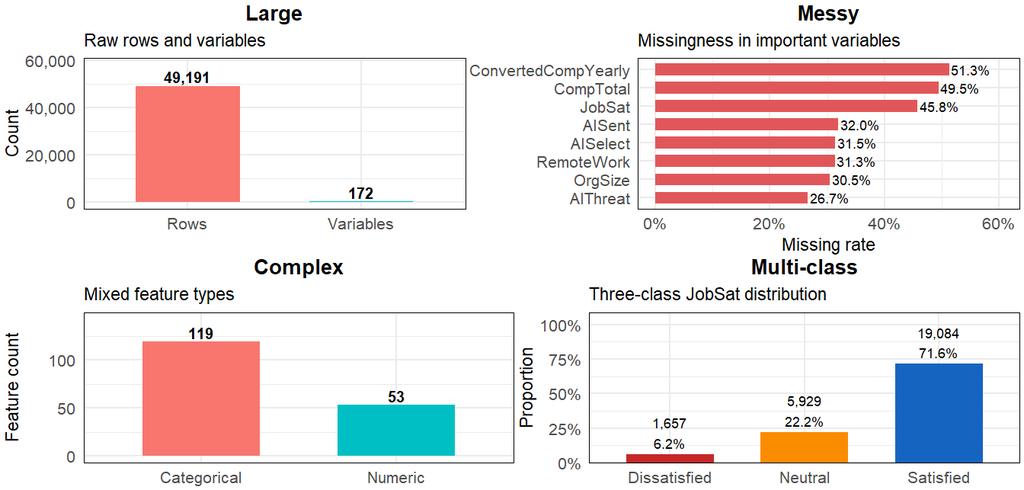

```r
### ============================================================
### Dataset suitability evidence
### ============================================================

set.seed(123)
data_path <- "survey_results_public.csv"
df <- read_csv(data_path, show_col_types = FALSE)

### --- Step 1: Create 3-class target variable ---

df <- df %>%
  mutate(
    JobSat = as.numeric(JobSat),
    JobSat_Class = case_when(
      JobSat <= 3  ~ "Dissatisfied",
      JobSat <= 6  ~ "Neutral",
      JobSat <= 10 ~ "Satisfied",
      TRUE ~ NA_character_
    ),
    JobSat_Class = factor(
      JobSat_Class,
      levels = c("Dissatisfied", "Neutral", "Satisfied")
    )
  )

### --- Step 2: Summarise dataset size and feature types ---

feature_cols <- setdiff(names(df), "JobSat_Class")

num_features <- sum(sapply(df[feature_cols], is.numeric))
cat_features <- sum(sapply(df[feature_cols], is.character))
other_features <- length(feature_cols) - num_features - cat_features
valid_target_n <- sum(!is.na(df$JobSat_Class))

size_df <- data.frame(
  Metric = c("Rows", "Variables"),
  Count = c(nrow(df), length(feature_cols))
)

feature_type_df <- data.frame(
  Type = c("Numeric", "Categorical", "Other"),
  Count = c(num_features, cat_features, other_features)
) %>%
  filter(Count > 0)

### --- Step 3: Measure missingness in important variables ---

vars_for_missing <- c(
  "JobSat", "ConvertedCompYearly", "CompTotal", "OrgSize",
  "RemoteWork", "WorkExp", "YearsCode", "AISelect",
  "AISent", "AIThreat", "DevType", "Employment"
)

vars_for_missing <- vars_for_missing[vars_for_missing %in% names(df)]

missing_df <- df %>%
  select(all_of(vars_for_missing)) %>%
  summarise(across(everything(), ~ mean(is.na(.)))) %>%
  pivot_longer(
    cols = everything(),
    names_to = "Variable",
    values_to = "MissingRate"
  ) %>%
  arrange(desc(MissingRate)) %>%
  slice_head(n = 8)

### --- Step 4: Summarise target class distribution ---

target_df <- df %>%
  filter(!is.na(JobSat_Class)) %>%
  count(JobSat_Class) %>%
  mutate(Proportion = n / sum(n))

### --- Step 5: Visualise dataset suitability evidence ---

p_large <- ggplot(size_df, aes(x = Metric, y = Count, fill = Metric)) +
  geom_col(show.legend = FALSE, width = 0.6) +
  geom_text(
    aes(label = comma(Count)),
    vjust = -0.3,
    size = 2.6,
    fontface = "bold"
  ) +
  scale_y_continuous(
    labels = comma,
    limits = c(0, max(size_df$Count) * 1.18)
  ) +
  labs(
    title = "Large",
    subtitle = "Raw rows and variables",
    x = NULL,
    y = "Count"
  ) +
  theme_minimal(base_size = 8.5) +
  theme(
  plot.title = element_text(hjust = 0.5, face = "bold", size = 10),
  plot.subtitle = element_text(size = 8.5),
  axis.title = element_text(size = 8.5),
  axis.text = element_text(size = 8),
  plot.margin = margin(2, 2, 2, 2),
  panel.border = element_rect(color = "black", fill = NA, linewidth = 0.35)
)

p_messy <- ggplot(missing_df, aes(x = MissingRate, y = reorder(Variable, MissingRate))) +
  geom_col(fill = "#E15759", width = 0.65) +
  geom_text(
    aes(label = percent(MissingRate, accuracy = 0.1)),
    hjust = -0.05,
    size = 2.4
  ) +
  scale_x_continuous(
    labels = percent_format(),
    limits = c(0, max(missing_df$MissingRate) * 1.18)
  ) +
  labs(
    title = "Messy",
    subtitle = "Missingness in important variables",
    x = "Missing rate",
    y = NULL
  ) +
  theme_minimal(base_size = 8.5) +
  theme(
  plot.title = element_text(hjust = 0.5, face = "bold", size = 10),
  plot.subtitle = element_text(size = 8.5),
  axis.title = element_text(size = 8.5),
  axis.text = element_text(size = 8),
  plot.margin = margin(2, 2, 2, 2),
  panel.border = element_rect(color = "black", fill = NA, linewidth = 0.35)
)

p_complex <- ggplot(feature_type_df, aes(x = Type, y = Count, fill = Type)) +
  geom_col(show.legend = FALSE, width = 0.6) +
  geom_text(
    aes(label = Count),
    vjust = -0.3,
    size = 2.6,
    fontface = "bold"
  ) +
  scale_y_continuous(
    limits = c(0, max(feature_type_df$Count) * 1.2)
  ) +
  labs(
    title = "Complex",
    subtitle = "Mixed feature types",
    x = NULL,
    y = "Feature count"
  ) +
  theme_minimal(base_size = 8.5) +
  theme(
  plot.title = element_text(hjust = 0.5, face = "bold", size = 10),
  plot.subtitle = element_text(size = 8.5),
  axis.title = element_text(size = 8.5),
  axis.text = element_text(size = 8),
  plot.margin = margin(2, 2, 2, 2),
  panel.border = element_rect(color = "black", fill = NA, linewidth = 0.35)
)

p_target <- ggplot(target_df, aes(x = JobSat_Class, y = Proportion, fill = JobSat_Class)) +
  geom_col(show.legend = FALSE, width = 0.65) +
  geom_text(
    aes(label = paste0(comma(n), "\n", percent(Proportion, accuracy = 0.1))),
    vjust = -0.2,
    size = 2.4
  ) +
  scale_y_continuous(
  labels = percent_format(),
  limits = c(0, max(target_df$Proportion) * 1.45),
  expand = expansion(mult = c(0, 0.05))
) +
  scale_fill_manual(values = c(
    "Dissatisfied" = "#C62828",
    "Neutral" = "#FB8C00",
    "Satisfied" = "#1565C0"
  )) +
  labs(
    title = "Multi-class",
    subtitle = "Three-class JobSat distribution",
    x = NULL,
    y = "Proportion"
  ) +
  theme_minimal(base_size = 8.5) +
  theme(
  plot.title = element_text(hjust = 0.5, face = "bold", size = 10),
  plot.subtitle = element_text(size = 8.5),
  axis.title = element_text(size = 8.5),
  axis.text = element_text(size = 8),
  plot.margin = margin(2, 2, 2, 2),
  panel.border = element_rect(color = "black", fill = NA, linewidth = 0.35)
)

(p_large + p_messy) / (p_complex + p_target) +
  plot_layout(heights = c(1, 1)) &
  theme(plot.margin = margin(1, 1, 1, 1))
```

The table below summarises the dataset suitability evidence:

```r
dataset_summary <- data.frame(
  Requirement = c("Large", "Messy", "Complex", "Multi-class"),
  Evidence = c(
    paste0(format(nrow(df), big.mark = ","), " rows and ", length(feature_cols), " variables"),
    "Important variables such as JobSat, salary, organisation size and AI-related fields contain missing values",
    paste0(num_features, " numeric variables and ", cat_features, " categorical variables"),
    paste0(format(valid_target_n, big.mark = ","), " valid JobSat responses recoded into 3 classes")
  ),
  Rationale = c(
    "Meets the large dataset requirement",
    "Requires cleaning and careful preprocessing",
    "Provides mixed feature types for classification",
    "Supports a supervised multi-class prediction task"
  )
)

kable(dataset_summary, align = "lll") %>%
  kable_styling(
    bootstrap_options = c("striped","hover","condensed"),
    full_width = TRUE,
    font_size = 9
  )
```

| Requirement | Evidence | Rationale |
| --- | --- | --- |
| Large | 49,191 rows and 172 variables | Meets the large dataset requirement |
| Messy | Important variables such as JobSat, salary, organisation size and AI-related fields contain missing values | Requires cleaning and careful preprocessing |
| Complex | 53 numeric variables and 119 categorical variables | Provides mixed feature types for classification |
| Multi-class | 26,670 valid JobSat responses recoded into 3 classes | Supports a supervised multi-class prediction task |

Overall, the dataset satisfies four project requirements. It is **large** because it contains **49,191** rows and **172** variables. It is **messy** because several important variables contain missing values. It is **complex** because it contains both numeric and categorical variables. It also supports a **multi-class classification task** because the original `JobSat` score is recoded into Dissatisfied, Neutral, and Satisfied. Since the target distribution is imbalanced, later model evaluation should use Macro F1 and Kappa rather than accuracy alone.

### 3 EDA & Insights

This section explores whether the existing predictors can clearly distinguish three levels of job satisfaction. The dataset is large and contains many variables, but if the dissatisfied, neutral and satisfied developers have similar characteristic patterns, the classification task will still be difficult. Salary, work experience and PCA are used to examine class overlap from both individual-variable and multi-variable perspectives.

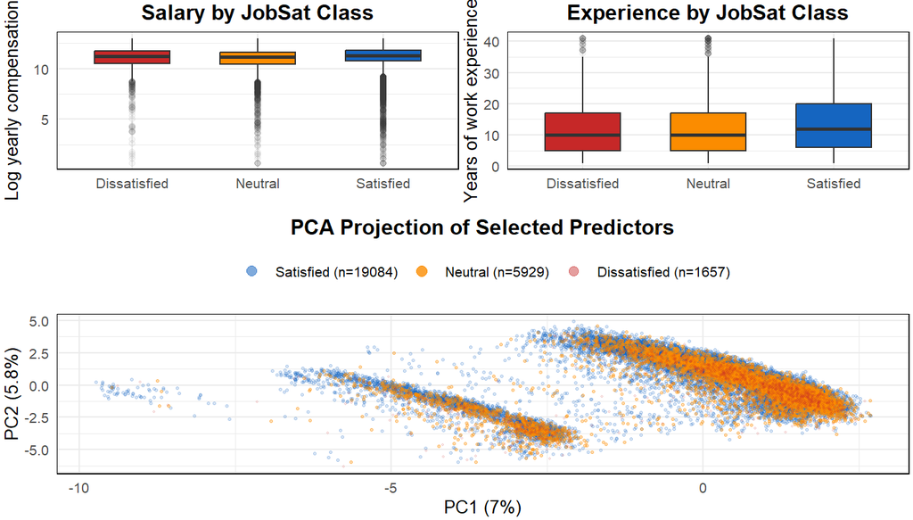

```r
### ============================================================
### EDA: feature overlap and class separability
### ============================================================

### --- Helper functions ---

convert_years <- function(x) {
  x <- as.character(x)
  x[x == "Less than 1 year"] <- "0.5"
  x[x == "More than 50 years"] <- "51"
  as.numeric(x)
}

count_multiresponse <- function(x) {
  x <- as.character(x)
  ifelse(is.na(x) | x == "", NA_real_, stringr::str_count(x, ";") + 1)
}

cap_numeric <- function(x, lower_prob = 0.01, upper_prob = 0.99) {
  x <- as.numeric(x)
  if (all(is.na(x))) return(rep(0, length(x)))

  lower <- quantile(x, lower_prob, na.rm = TRUE)
  upper <- quantile(x, upper_prob, na.rm = TRUE)

  x <- ifelse(!is.na(x) & x < lower, lower, x)
  x <- ifelse(!is.na(x) & x > upper, upper, x)

  med <- median(x, na.rm = TRUE)
  if (is.na(med)) med <- 0

  x[is.na(x)] <- med
  x
}

clean_factor <- function(x, top_n = 5) {
  x <- as.character(x)
  x[is.na(x) | x == ""] <- "Missing"

  top_levels <- names(sort(table(x), decreasing = TRUE))[1:min(top_n, length(unique(x)))]
  x[!(x %in% top_levels)] <- "Other"

  factor(x)
}

### --- Step 1: Check required variables ---

needed_cols <- c(
  "ConvertedCompYearly", "WorkExp", "YearsCode", "Age",
  "EdLevel", "RemoteWork", "OrgSize", "ICorPM",
  "AISent", "AIAcc", "AIThreat", "NewRole",
  "PurchaseInfluence"
)

for (col in needed_cols) {
  if (!(col %in% names(df))) {
    df[[col]] <- NA
  }
}

### --- Step 2: Create tool-count features from multi-response columns ---

work_tool_cols <- intersect(
  c(
    "LanguageHaveWorkedWith",
    "DatabaseHaveWorkedWith",
    "PlatformHaveWorkedWith",
    "WebframeHaveWorkedWith",
    "MiscTechHaveWorkedWith",
    "ToolsTechHaveWorkedWith",
    "NEWCollabToolsHaveWorkedWith"
  ),
  names(df)
)

if (length(work_tool_cols) > 0) {
  df$ToolCountWork <- rowSums(
    as.data.frame(lapply(work_tool_cols, function(v) {
      replace_na(count_multiresponse(df[[v]]), 0)
    })),
    na.rm = TRUE
  )
} else {
  df$ToolCountWork <- NA_real_
}

personal_tool_cols <- intersect(
  c(
    "LanguageWantToWorkWith",
    "DatabaseWantToWorkWith",
    "PlatformWantToWorkWith",
    "WebframeWantToWorkWith",
    "MiscTechWantToWorkWith",
    "ToolsTechWantToWorkWith",
    "NEWCollabToolsWantToWorkWith"
  ),
  names(df)
)

if (length(personal_tool_cols) > 0) {
  df$ToolCountPersonal <- rowSums(
    as.data.frame(lapply(personal_tool_cols, function(v) {
      replace_na(count_multiresponse(df[[v]]), 0)
    })),
    na.rm = TRUE
  )
} else {
  df$ToolCountPersonal <- NA_real_
}

### --- Step 3: Build EDA dataset ---

eda_df <- df %>%
  mutate(
    WorkExp = as.numeric(WorkExp),
    YearsCode = convert_years(YearsCode),
    ConvertedCompYearly = as.numeric(ConvertedCompYearly),
    ToolCountWork = as.numeric(ToolCountWork),
    ToolCountPersonal = as.numeric(ToolCountPersonal),
    LogSalary = log1p(ConvertedCompYearly)
  ) %>%
  filter(!is.na(JobSat_Class))

### --- Step 4: Prepare salary and work experience plots ---

plot_data <- eda_df %>%
  filter(!is.na(WorkExp), !is.na(LogSalary), is.finite(LogSalary)) %>%
  mutate(
    WorkExp = pmin(WorkExp, quantile(WorkExp, 0.99, na.rm = TRUE)),
    LogSalary = pmin(LogSalary, quantile(LogSalary, 0.99, na.rm = TRUE))
  )

p_salary <- ggplot(plot_data, aes(x = JobSat_Class, y = LogSalary, fill = JobSat_Class)) +
  geom_boxplot(outlier.alpha = 0.05, width = 0.6, show.legend = FALSE) +
  scale_fill_manual(values = c(
    "Dissatisfied" = "#C62828",
    "Neutral" = "#FB8C00",
    "Satisfied" = "#1565C0"
  )) +
  labs(
    title = "Salary by JobSat Class",
    x = NULL,
    y = "Log yearly compensation"
  ) +
  theme_minimal(base_size = 10) +
  theme(
    plot.title = element_text(hjust = 0.5, face = "bold"),
    panel.border = element_rect(color = "black", fill = NA, linewidth = 0.4)
  )

p_work <- ggplot(plot_data, aes(x = JobSat_Class, y = WorkExp, fill = JobSat_Class)) +
  geom_boxplot(outlier.alpha = 0.05, width = 0.6, show.legend = FALSE) +
  scale_fill_manual(values = c(
    "Dissatisfied" = "#C62828",
    "Neutral" = "#FB8C00",
    "Satisfied" = "#1565C0"
  )) +
  labs(
    title = "Experience by JobSat Class",
    x = NULL,
    y = "Years of work experience"
  ) +
  theme_minimal(base_size = 10) +
  theme(
    plot.title = element_text(hjust = 0.5, face = "bold"),
    panel.border = element_rect(color = "black", fill = NA, linewidth = 0.4)
  )

### --- Step 5: Prepare predictors for PCA ---

pca_df <- eda_df %>%
  transmute(
    JobSat_Class,
    WorkExp,
    YearsCode,
    ToolCountWork,
    ToolCountPersonal,
    LogSalary,
    Age,
    EdLevel,
    RemoteWork,
    OrgSize,
    ICorPM,
    AISent,
    AIAcc,
    AIThreat,
    NewRole,
    PurchaseInfluence
  )

numeric_vars <- c(
  "WorkExp", "YearsCode", "ToolCountWork",
  "ToolCountPersonal", "LogSalary"
)

categorical_vars <- setdiff(names(pca_df), c("JobSat_Class", numeric_vars))

for (v in numeric_vars) {
  pca_df[[v]] <- cap_numeric(pca_df[[v]], 0.01, 0.99)
}

for (v in categorical_vars) {
  pca_df[[v]] <- clean_factor(pca_df[[v]], top_n = 5)
}

### --- Step 6: Run PCA after dummy encoding categorical variables ---

x_mat <- model.matrix(~ . - JobSat_Class - 1, data = pca_df)

keep_cols <- apply(x_mat, 2, sd) > 0
x_mat <- x_mat[, keep_cols, drop = FALSE]
x_mat <- scale(x_mat)

pca_fit <- prcomp(x_mat, center = FALSE, scale. = FALSE)
var_exp <- round(100 * summary(pca_fit)$importance[2, 1:2], 1)

pca_plot_df <- tibble(
  PC1 = pca_fit$x[, 1],
  PC2 = pca_fit$x[, 2],
  JobSat_Class = factor(
    pca_df$JobSat_Class,
    levels = c("Satisfied", "Neutral", "Dissatisfied")
  )
)

if (
  median(pca_plot_df$PC1[pca_plot_df$JobSat_Class == "Satisfied"], na.rm = TRUE) <
  median(pca_plot_df$PC1[pca_plot_df$JobSat_Class == "Dissatisfied"], na.rm = TRUE)
) {
  pca_plot_df$PC1 <- -pca_plot_df$PC1
}

class_counts <- pca_plot_df %>%
  count(JobSat_Class) %>%
  mutate(label = paste0(JobSat_Class, " (n=", n, ")"))

legend_labels <- setNames(class_counts$label, class_counts$JobSat_Class)

### --- Step 7: Visualise feature overlap and PCA projection ---

p_pca <- ggplot() +
  geom_point(
    data = pca_plot_df %>% filter(JobSat_Class == "Satisfied"),
    aes(x = PC1, y = PC2, color = JobSat_Class),
    alpha = 0.18,
    size = 0.55
  ) +
  geom_point(
    data = pca_plot_df %>% filter(JobSat_Class == "Neutral"),
    aes(x = PC1, y = PC2, color = JobSat_Class),
    alpha = 0.34,
    size = 0.65
  ) +
  geom_point(
    data = pca_plot_df %>% filter(JobSat_Class == "Dissatisfied"),
    aes(x = PC1, y = PC2, color = JobSat_Class),
    alpha = 0.11,
    size = 0.48
  ) +
  scale_color_manual(
    values = c(
      "Satisfied" = "#1565C0",
      "Neutral" = "#FB8C00",
      "Dissatisfied" = "#C62828"
    ),
    breaks = c("Satisfied", "Neutral", "Dissatisfied"),
    labels = legend_labels
  ) +
  guides(
    color = guide_legend(
      override.aes = list(
        alpha = c(0.55, 0.80, 0.45),
        size = c(2.5, 2.7, 2.4)
      ),
      nrow = 1
    )
  ) +
  labs(
    title = "PCA Projection of Selected Predictors",
    x = paste0("PC1 (", var_exp[1], "%)"),
    y = paste0("PC2 (", var_exp[2], "%)"),
    color = NULL
  ) +
  theme_minimal(base_size = 10) +
  theme(
    plot.title = element_text(
      hjust = 0.5,
      face = "bold",
      margin = margin(t = 8, b = 10)
    ),
    legend.position = "top",
    legend.margin = margin(t = 0, b = 6),
    panel.border = element_rect(color = "black", fill = NA, linewidth = 0.4),
    plot.margin = margin(t = 8, r = 5, b = 5, l = 5)
  )

(p_salary + p_work) / plot_spacer() / p_pca +
  plot_layout(heights = c(0.62, 0.03, 0.72)) &
  theme(plot.margin = margin(1, 1, 1, 1))
```

The table below summarises the main EDA findings:

```r
eda_summary <- data.frame(
  Evidence = c(
    "Salary distribution",
    "Work experience distribution",
    "PCA projection"
  ),
  Finding = c(
    "The median values differ slightly, but the three classes overlap strongly",
    "The experience ranges are similar across satisfaction groups",
    "The first two principal components do not form clearly separated clusters"
  ),
  Implication = c(
    "Salary alone cannot clearly classify developer job satisfaction",
    "Work experience alone is not enough to separate the target classes",
    "The modelling task is limited by weak class separability"
  )
)

kable(eda_summary, align = "lll") %>%
  kable_styling(
    bootstrap_options = c("striped","hover","condensed"),
    full_width = TRUE,
    font_size = 9
  )
```

| Evidence | Finding | Implication |
| --- | --- | --- |
| Salary distribution | The median values differ slightly, but the three classes overlap strongly | Salary alone cannot clearly classify developer job satisfaction |
| Work experience distribution | The experience ranges are similar across satisfaction groups | Work experience alone is not enough to separate the target classes |
| PCA projection | The first two principal components do not form clearly separated clusters | The modelling task is limited by weak class separability |

The EDA shows that salary and work experience differ slightly across the three satisfaction groups, but the distributions overlap heavily. PCA projection conveys the same message from a wider feature space. After the numerical variables are truncated and interpolated, and the category variables are grouped and virtually encoded, the first two main components still show a strong overlap between dissatisfied, neutral and satisfied developers.

This shows that the main challenge of modelling is **weak class separability**. The dataset contains useful signals, but these signals are scattered in multiple predictors instead of forming clear class boundaries. This explains why the comparison of subsequent models should use macro F1 values and Kappa coefficients, not just accuracy.

### 4 Data Preprocessing

This study uses the **Stack Overflow 2025 Developer Survey** (49,191 responses, 172 variables) to predict developer job satisfaction. The original 0–10 `JobSat` score is discretised into 3 classes: Dissatisfied (0–3), Neutral (4–6), and Satisfied (7–10).

```r
### ============================================================
### Shared preprocessing pipeline
### All parameters learned from training set only (no data leakage)
### ============================================================

set.seed(123)
data_path <- "survey_results_public.csv"
df <- read_csv(data_path, show_col_types = FALSE)

### --- Helper functions ---

convert_years <- function(x) {
  x <- as.character(x)
  x[x == "Less than 1 year"] <- "0.5"
  x[x == "More than 50 years"] <- "51"
  as.numeric(x)
}

safe_median <- function(x) {
  med <- median(x, na.rm = TRUE)
  ifelse(is.na(med), 0, med)
}

safe_quantile <- function(x, prob = 0.99) {
  if (all(is.na(x))) return(0)
  q <- quantile(x, probs = prob, na.rm = TRUE)
  ifelse(is.na(q), max(x, na.rm = TRUE), q)
}

safe_remove_vars <- function(data, vars) {
  vars <- vars[!is.na(vars) & vars != "" & vars %in% names(data)]
  if (length(vars) > 0) data <- data %>% select(-any_of(vars))
  data
}

is_near_zero_var <- function(x, freq_cut = 95 / 5, unique_cut = 10) {
  x <- as.character(x); x <- x[!is.na(x)]
  if (length(x) == 0) return(TRUE)
  tab <- sort(table(x), decreasing = TRUE)
  if (length(tab) == 1) return(TRUE)
  freq_ratio <- as.numeric(tab[1] / tab[2])
  percent_unique <- length(unique(x)) / length(x) * 100
  freq_ratio > freq_cut && percent_unique < unique_cut
}

### --- Step 1: Select 22 candidate predictors + create 5-class target ---

gbm_raw <- df %>%
  mutate(
    JobSat = as.numeric(JobSat),
    JobSat_Class = case_when(
      JobSat <= 1  ~ "Very_Dissatisfied",
      JobSat <= 3  ~ "Dissatisfied",
      JobSat <= 6  ~ "Neutral",
      JobSat <= 8  ~ "Satisfied",
      JobSat <= 10 ~ "Very_Satisfied",
      TRUE ~ NA_character_
    ),
    JobSat_Class = factor(JobSat_Class,
      levels = c("Very_Dissatisfied","Dissatisfied","Neutral",
                 "Satisfied","Very_Satisfied")),
    YearsCode = convert_years(YearsCode),
    WorkExp = as.numeric(WorkExp),
    ConvertedCompYearly = as.numeric(ConvertedCompYearly)
  ) %>%
  select(any_of(c(
    "JobSat_Class",
    "Age","EdLevel","Employment","RemoteWork","WorkExp","YearsCode",
    "OrgSize","ICorPM","Country","DevType","Industry",
    "AISelect","AISent","AIAcc","AIThreat",
    "NewRole","TechEndorseIntro","PurchaseInfluence",
    "ToolCountWork","ToolCountPersonal","ConvertedCompYearly"
  ))) %>%
  filter(!is.na(JobSat_Class))

### --- Step 2: Stratified 80/20 train-test split BEFORE any preprocessing ---

train_index <- createDataPartition(gbm_raw$JobSat_Class, p = 0.8, list = FALSE)
train_raw <- gbm_raw[train_index, ]
test_raw  <- gbm_raw[-train_index, ]

### --- Step 3: Fit preprocessing rules on training data only ---

fit_gbm_preprocess <- function(train_data) {
  missing_rates <- sapply(train_data, function(x) mean(is.na(x)))
  high_missing_vars <- names(missing_rates)[
    missing_rates > 0.80 & names(missing_rates) != "JobSat_Class"]
  high_missing_vars <- high_missing_vars[!is.na(high_missing_vars) & high_missing_vars != ""]
  train_data_reduced <- safe_remove_vars(train_data, high_missing_vars)

  numeric_vars <- intersect(c("WorkExp","YearsCode","ToolCountWork","ToolCountPersonal"),
                            names(train_data_reduced))
  numeric_medians <- list()
  for (v in numeric_vars) numeric_medians[[v]] <- safe_median(train_data_reduced[[v]])

  workexp_cap <- if ("WorkExp" %in% names(train_data_reduced))
    safe_quantile(train_data_reduced$WorkExp, 0.99) else NA
  yearscode_cap <- if ("YearsCode" %in% names(train_data_reduced))
    safe_quantile(train_data_reduced$YearsCode, 0.99) else NA
  salary_cap <- if ("ConvertedCompYearly" %in% names(train_data_reduced))
    safe_quantile(train_data_reduced$ConvertedCompYearly, 0.99) else NA

  if ("ConvertedCompYearly" %in% names(train_data_reduced)) {
    salary_temp <- train_data_reduced$ConvertedCompYearly
    salary_temp[salary_temp < 0] <- NA
    salary_temp <- ifelse(salary_temp > salary_cap, salary_cap, salary_temp)
    log_salary_median <- safe_median(log1p(salary_temp))
  } else { log_salary_median <- 0 }

  multi_response_candidates <- intersect(
    c("DevType","Employment","AISelect","AISent","AIAcc","AIThreat",
      "NewRole","TechEndorseIntro","PurchaseInfluence"),
    names(train_data_reduced))
  multi_response_vars <- c(); multi_response_terms <- list()
  for (v in multi_response_candidates) {
    x <- as.character(train_data_reduced[[v]])
    if (any(str_detect(x[!is.na(x)], fixed(";")))) {
      multi_response_vars <- c(multi_response_vars, v)
      sv <- trimws(unlist(strsplit(x[!is.na(x)], ";", fixed = TRUE)))
      sv <- sv[sv != ""]
      vc <- sort(table(sv), decreasing = TRUE)
      multi_response_terms[[v]] <- names(vc)[1:min(15, length(vc))]
    }
  }

  categorical_vars <- setdiff(
    intersect(c("Age","EdLevel","RemoteWork","OrgSize","ICorPM","Country","Industry",
                "AISelect","AISent","AIAcc","AIThreat","Employment","DevType",
                "NewRole","TechEndorseIntro","PurchaseInfluence"),
              names(train_data_reduced)),
    multi_response_vars)
  top_levels <- list()
  for (v in categorical_vars) {
    x <- as.character(train_data_reduced[[v]]); x[is.na(x)] <- "Missing"
    lc <- sort(table(x), decreasing = TRUE)
    top_levels[[v]] <- names(lc)[1:min(15, length(lc))]
  }

  list(high_missing_vars = high_missing_vars,
       numeric_vars = numeric_vars, numeric_medians = numeric_medians,
       workexp_cap = workexp_cap, yearscode_cap = yearscode_cap,
       salary_cap = salary_cap, log_salary_median = log_salary_median,
       categorical_vars = categorical_vars, top_levels = top_levels,
       multi_response_vars = multi_response_vars, multi_response_terms = multi_response_terms)
}

### --- Step 4: Apply preprocessing to both train and test ---

apply_gbm_preprocess <- function(data, prep) {
  data <- safe_remove_vars(data, prep$high_missing_vars)
  if ("WorkExp"             %in% names(data)) data$Missing_WorkExp             <- ifelse(is.na(data$WorkExp), 1, 0)
  if ("YearsCode"           %in% names(data)) data$Missing_YearsCode           <- ifelse(is.na(data$YearsCode), 1, 0)
  if ("ConvertedCompYearly" %in% names(data)) data$Missing_ConvertedCompYearly <- ifelse(is.na(data$ConvertedCompYearly), 1, 0)
  if ("OrgSize"             %in% names(data)) data$Missing_OrgSize             <- ifelse(is.na(data$OrgSize), 1, 0)
  if ("WorkExp" %in% names(data)) {
    data$WorkExp[data$WorkExp < 0] <- NA
    data$WorkExp <- ifelse(!is.na(data$WorkExp) & data$WorkExp > prep$workexp_cap, prep$workexp_cap, data$WorkExp)
    data$WorkExp[is.na(data$WorkExp)] <- prep$numeric_medians[["WorkExp"]]
  }
  if ("YearsCode" %in% names(data)) {
    data$YearsCode[data$YearsCode < 0] <- NA
    data$YearsCode <- ifelse(!is.na(data$YearsCode) & data$YearsCode > prep$yearscode_cap, prep$yearscode_cap, data$YearsCode)
    data$YearsCode[is.na(data$YearsCode)] <- prep$numeric_medians[["YearsCode"]]
  }
  for (v in setdiff(prep$numeric_vars, c("WorkExp","YearsCode"))) {
    if (v %in% names(data)) data[[v]][is.na(data[[v]])] <- prep$numeric_medians[[v]]
  }
  if ("ConvertedCompYearly" %in% names(data)) {
    data$ConvertedCompYearly[data$ConvertedCompYearly < 0] <- NA
    data$ConvertedCompYearly <- ifelse(!is.na(data$ConvertedCompYearly) & data$ConvertedCompYearly > prep$salary_cap, prep$salary_cap, data$ConvertedCompYearly)
    data$LogConvertedCompYearly <- log1p(data$ConvertedCompYearly)
    data$LogConvertedCompYearly[is.na(data$LogConvertedCompYearly)] <- prep$log_salary_median
    data$ConvertedCompYearly <- NULL
  }
  for (v in prep$categorical_vars) {
    if (v %in% names(data)) {
      x <- as.character(data[[v]]); x[is.na(x)] <- "Missing"
      x[!(x %in% prep$top_levels[[v]])] <- "Other"
      data[[v]] <- factor(x, levels = unique(c(prep$top_levels[[v]], "Other", "Missing")))
    }
  }
  for (v in prep$multi_response_vars) {
    if (v %in% names(data)) {
      raw_x <- as.character(data[[v]]); raw_x[is.na(raw_x)] <- ""
      padded_x <- paste0(";", raw_x, ";")
      for (term in prep$multi_response_terms[[v]]) {
        data[[paste0(v, "_", make.names(term))]] <-
          ifelse(str_detect(padded_x, fixed(paste0(";", term, ";"))), 1, 0)
      }
      data[[v]] <- NULL
    }
  }
  data
}

gbm_prep   <- fit_gbm_preprocess(train_raw)
train_data <- apply_gbm_preprocess(train_raw, gbm_prep)
test_data  <- apply_gbm_preprocess(test_raw,  gbm_prep)

levels_order <- c("Very_Dissatisfied","Dissatisfied","Neutral","Satisfied","Very_Satisfied")
train_data$JobSat_Class <- factor(train_data$JobSat_Class, levels = levels_order)
test_data$JobSat_Class  <- factor(test_data$JobSat_Class,  levels = levels_order)

### --- Step 5: Feature engineering — LeavingScore ---

leaving_map <- c(
  "I have strongly considered changing my career and/or the industry I work in" = 4,
  "I have somewhat considered changing my career and/or the industry I work in" = 3,
  "I have transitioned into a new career and/or industry involuntarily"         = 2,
  "I have neither consider or transitioned into a new career or industry"       = 1,
  "I have transitioned into a new career and/or industry voluntarily"           = 0)

add_leaving_score <- function(data, median_value) {
  if ("NewRole" %in% names(data)) {
    nr_char <- as.character(data$NewRole)
    data$LeavingScore <- leaving_map[nr_char]
    data$LeavingScore[is.na(data$LeavingScore)] <- median_value
  }
  data
}

train_leaving_raw <- leaving_map[as.character(train_data$NewRole)]
leaving_median <- median(train_leaving_raw, na.rm = TRUE)
train_data <- add_leaving_score(train_data, leaving_median)
test_data  <- add_leaving_score(test_data,  leaving_median)

### --- Step 6: Feature selection ---

predictor_names <- setdiff(names(train_data), "JobSat_Class")
nzv_vars <- predictor_names[sapply(train_data[predictor_names], is_near_zero_var)]
nzv_vars <- nzv_vars[!is.na(nzv_vars) & nzv_vars != "" & nzv_vars %in% names(train_data)]
train_data <- safe_remove_vars(train_data, nzv_vars)
test_data  <- safe_remove_vars(test_data,  nzv_vars)

numeric_predictors <- names(train_data)[sapply(train_data, is.numeric) & names(train_data) != "JobSat_Class"]
numeric_predictors <- numeric_predictors[!is.na(numeric_predictors) & numeric_predictors != "" & numeric_predictors %in% names(train_data)]
numeric_predictors <- numeric_predictors[sapply(train_data[numeric_predictors], function(x) sd(x, na.rm = TRUE) > 0)]
high_corr_vars <- character(0)
if (length(numeric_predictors) > 1) {
  corr_matrix <- cor(train_data[numeric_predictors], use = "pairwise.complete.obs")
  corr_matrix[is.na(corr_matrix)] <- 0
  high_corr_index <- findCorrelation(corr_matrix, cutoff = 0.90, names = FALSE)
  if (length(high_corr_index) > 0) high_corr_vars <- numeric_predictors[high_corr_index]
}
high_corr_vars <- high_corr_vars[!is.na(high_corr_vars) & high_corr_vars != "" & high_corr_vars %in% names(train_data)]
train_data <- safe_remove_vars(train_data, high_corr_vars)
test_data  <- safe_remove_vars(test_data,  high_corr_vars)

### --- Step 7: Remap to 3-class ---

remap_to_3class <- function(x) {
  factor(case_when(
    x %in% c("Very_Dissatisfied","Dissatisfied") ~ "Dissatisfied",
    x == "Neutral" ~ "Neutral",
    x %in% c("Satisfied","Very_Satisfied") ~ "Satisfied",
    TRUE ~ NA_character_
  ), levels = c("Dissatisfied","Neutral","Satisfied"))
}

train_3 <- train_data; test_3 <- test_data
train_3$JobSat_Class <- remap_to_3class(train_data$JobSat_Class)
test_3$JobSat_Class  <- remap_to_3class(test_data$JobSat_Class)
```

The table below summarises each preprocessing step:

```r
steps_df <- data.frame(
  Step = c("Initial selection", "High-missingness removal (>80% NA)",
           "Missing indicators", "Numeric capping + median imputation",
           "Salary log transformation", "Rare category merging (top 15 levels)",
           "Multi-response binarisation", "LeavingScore feature engineering",
           "Near-zero variance removal", "High-correlation removal (r > 0.90)"),
  Rationale = c(
    "Select 22 domain-relevant predictors from 172 survey columns",
    "Variables with excessive missingness cannot be reliably imputed",
    "Create binary flags for WorkExp, YearsCode, Salary, OrgSize missingness",
    "Cap at 99th percentile to limit outlier influence; impute with training median",
    "Right-skewed salary distribution normalised via log1p; NA filled with training median",
    "Prevent sparse levels from causing overfitting; rare categories grouped as 'Other'",
    "Semicolon-delimited columns (DevType, Employment, etc.) split into binary indicators",
    "Ordinal encoding of NewRole into 0-4 career-change propensity score",
    "Remove predictors where dominant class ratio exceeds 95/5",
    "Remove redundant numeric predictors to reduce multicollinearity"))
kable(steps_df, align = "ll") %>%
  kable_styling(bootstrap_options = c("striped","hover","condensed"), full_width = TRUE, font_size = 12)
```

| Step | Rationale |
| --- | --- |
| Initial selection | Select 22 domain-relevant predictors from 172 survey columns |
| High-missingness removal (>80% NA) | Variables with excessive missingness cannot be reliably imputed |
| Missing indicators | Create binary flags for WorkExp, YearsCode, Salary, OrgSize missingness |
| Numeric capping + median imputation | Cap at 99th percentile to limit outlier influence; impute with training median |
| Salary log transformation | Right-skewed salary distribution normalised via log1p; NA filled with training median |
| Rare category merging (top 15 levels) | Prevent sparse levels from causing overfitting; rare categories grouped as ‘Other’ |
| Multi-response binarisation | Semicolon-delimited columns (DevType, Employment, etc.) split into binary indicators |
| LeavingScore feature engineering | Ordinal encoding of NewRole into 0-4 career-change propensity score |
| Near-zero variance removal | Remove predictors where dominant class ratio exceeds 95/5 |
| High-correlation removal (r > 0.90) | Remove redundant numeric predictors to reduce multicollinearity |

After preprocessing: **21338** training samples, **5332** test samples, **24** features.(The rows lacking JobSat were deleted.)

### 5 Model Fitting

We fitted five classification models with different levels of complexity: Naive Bayes, Multinomial Logistic Regression, Random Forest, Gradient Boosting and a Deep Neural Network (DNN). Naive Bayes and Multinomial Logistic Regression were used as baseline models, while Random Forest, Gradient Boosting and the DNN were used to test whether more flexible methods could improve predictive performance. To ensure a fair comparison, all models were trained and tested using the same train/test split and evaluated using the same metrics. During the training process, an appropriate method was applied for each model to address class imbalance. Due to the computational cost of model fitting and tuning, these steps were completed in the `run_all_models.R` file. The final training code is provided in the foldable sections below, and the saved model results are loaded from `.rds` files for reporting.

These models were chosen because they provide different ways of handling the structure of the survey data. Multinomial Logistic Regression provides an interpretable linear benchmark after converting categorical variables into indicator variables and standardising numerical predictors. Naive Bayes provides a simple probabilistic benchmark that allows us to evaluate whether basic patterns in the predictors are sufficient to distinguish between satisfaction categories. Random Forest and Gradient Boosting are suitable for this dataset because they can capture non-linear relationships and interactions between predictors, such as employment conditions, professional background and attitudes towards AI tools. As a more flexible model, the DNN was included to learn complex patterns from the processed feature matrix. Comparing these models helps us determine whether increasing model complexity meaningfully improves the prediction of the three job satisfaction categories, particularly in the presence of class imbalance.

```r
### Load all pre-computed results
gbm_res <- readRDS("results/gbm_3class.rds")
dnn_res <- readRDS("results/dnn_3class.rds")
nb_res  <- readRDS("results/nb_3class.rds")
rf_res  <- readRDS("results/rf_3class.rds")
lr_res  <- readRDS("results/lr_3class.rds")
comparison <- readRDS("results/model_comparison.rds")

### Shared confusion matrix plot function
plot_cm <- function(cm_obj, title) {
  cm_df <- as.data.frame(cm_obj$table)
  names(cm_df) <- c("Predicted", "Actual", "Freq")
  cm_df <- cm_df %>% group_by(Actual) %>% mutate(Pct = Freq / sum(Freq)) %>% ungroup()
  ggplot(cm_df, aes(x = Actual, y = Predicted, fill = Pct)) +
    geom_tile(color = "white", linewidth = 0.8) +
    geom_text(aes(label = sprintf("%d\n(%.0f%%)", Freq, Pct * 100)), size = 3.5, fontface = "bold") +
    scale_fill_gradient(low = "#E3F2FD", high = "#1565C0", labels = scales::percent) +
    labs(title = title, x = "Actual", y = "Predicted", fill = "Rate") +
    theme_minimal(base_size = 11)
}
```

#### 5.1 Gradient Boosting (GBM)

Gradient Boosting builds a series of shallow decision trees, and each new tree aims to correct the errors of the current model. To reduce the impact of class imbalance, **square-root-based case weights** were applied during the training process. The final model was fitted using the best hyperparameter combination determined by 3-fold cross-validation. Details of the tuning process are provided in the Model Improvement section.

```r
### GBM: Final model with best hyperparameters (pre-computed)
make_class_weights <- function(y) {
  y <- factor(y); cc <- table(y)
  raw_w <- sqrt(max(cc) / cc)
  as.numeric(raw_w[as.character(y)])
}
best_grid_gbm <- gbm_tuned_3$bestTune
set.seed(123)
gbm_final_3 <- train(
  JobSat_Class ~ ., data = train_3, method = "gbm",
  trControl = trainControl(method = "none", classProbs = FALSE),
  tuneGrid = best_grid_gbm,
  weights = make_class_weights(train_3$JobSat_Class), verbose = FALSE)
gbm_pred_3 <- predict(gbm_final_3, newdata = test_3)
```

**Best parameters:** n.trees = 500, depth = 3, shrinkage = 0.03, min.node = 10. **Imbalance strategy:** sqrt case weights.

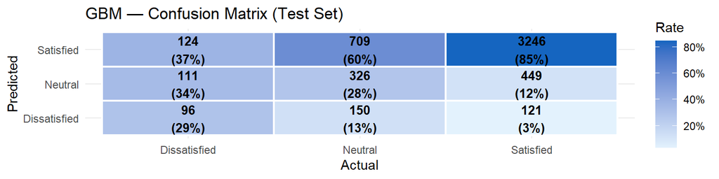

```r
plot_cm(gbm_res$confusion_matrix, "GBM — Confusion Matrix (Test Set)")
```

#### 5.2 Deep Neural Network (DNN)

A 3-layer feedforward network (Linear → ReLU → Dropout per layer) trained with **Focal Loss** ($FL = -\alpha_t(1-p_t)^\gamma \log p_t$, $\gamma = 2.0$), which dynamically down-weights easy samples and focuses on hard examples. The Neutral class receives an additional 1.5× weight boost. DNN-specific preprocessing includes one-hot encoding, Z-score standardisation (parameters from training set only), and value clipping to [-5, 5] (see Model Improvement for tuning details).

```r
### DNN: Final model with best hyperparameters (pre-computed)
### Requires: library(torch); library(luz)
### DNN-specific preprocessing: one-hot + Z-score (train params only) + clip [-5, 5]
X_train_raw <- train_data %>% select(-JobSat_Class)
X_test_raw  <- test_data  %>% select(-JobSat_Class)
X_train_raw$.__split__ <- "train"; X_test_raw$.__split__ <- "test"
combined <- bind_rows(X_train_raw, X_test_raw) %>% mutate(across(where(is.character), as.factor))
split_col <- combined$.__split__; combined$.__split__ <- NULL
X_onehot <- model.matrix(~ . - 1, data = combined)
X_train_oh <- X_onehot[split_col == "train", ]; X_test_oh <- X_onehot[split_col == "test", ]
train_means <- apply(X_train_oh, 2, mean); train_sds <- apply(X_train_oh, 2, sd)
train_sds[train_sds == 0] <- 1
X_train_mat <- as.matrix(pmax(pmin(scale(X_train_oh, center=train_means, scale=train_sds), 5), -5))
X_test_mat  <- as.matrix(pmax(pmin(scale(X_test_oh, center=train_means, scale=train_sds), 5), -5))

### Class weights: sqrt weighting + Neutral x1.5 boost
dnn_counts <- table(factor(y_train_dnn, levels = 1:3))
dnn_weights <- as.numeric(sqrt(length(y_train_dnn) / (3 * dnn_counts)))
dnn_weights <- dnn_weights / sum(dnn_weights) * 3
dnn_weights[2] <- dnn_weights[2] * 1.5
dnn_weights <- dnn_weights / sum(dnn_weights) * 3

### Train: 80 epochs, lr scheduler, early stopping (patience=15)
set.seed(123); torch_manual_seed(123)
dnn_final_model <- dnn_model %>%
  setup(loss = focal_loss_module(weight = class_weights_tensor, gamma = 2.0),
        optimizer = optim_adam, metrics = list(luz_metric_accuracy())) %>%
  set_hparams(n_features = n_features, n_classes = 3,
              hidden1 = best_dims$h1, hidden2 = best_dims$h2,
              hidden3 = best_dims$h3, dropout_rate = best_dnn$dropout_rate) %>%
  set_opt_hparams(lr = best_dnn$lr, weight_decay = 1e-4) %>%
  fit(data = final_train_dl, epochs = 80, valid_data = final_test_dl,
      callbacks = list(
        luz_callback_lr_scheduler(torch::lr_reduce_on_plateau, patience=5, factor=0.5),
        luz_callback_early_stopping(patience = 15)), verbose = TRUE)
```

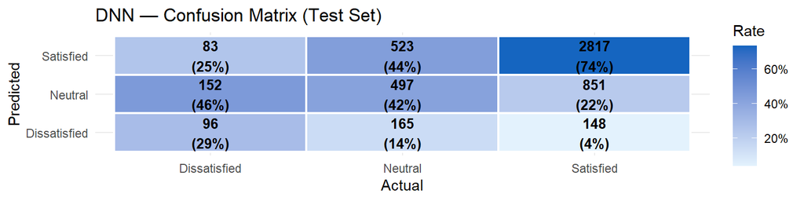

```r
plot_cm(dnn_res$confusion_matrix, "DNN — Confusion Matrix (Test Set)")
```

#### 5.3 Naive Bayes (NB)

Naive Bayes estimates class-conditional feature probabilities under a conditional independence assumption. Since NB cannot accept case weights, class imbalance is addressed via **SMOTE oversampling** (over_ratio = 0.8) applied to the training set only(see Model Improvement for tuning details).

```r
### NB: Final model with best hyperparameters (pre-computed)
### Uses shared train_3/test_3 for fair comparison (not re-split)
library(e1071); library(recipes); library(themis)
train_nb <- train_3; test_nb <- test_3
factor_cols_nb <- setdiff(names(train_nb)[sapply(train_nb, is.factor)], "JobSat_Class")
train_nb[factor_cols_nb] <- lapply(train_nb[factor_cols_nb], as.numeric)
test_nb[factor_cols_nb]  <- lapply(test_nb[factor_cols_nb], as.numeric)
rec_nb <- recipe(JobSat_Class ~ ., data = train_nb) %>%
  step_smote(JobSat_Class, over_ratio = 0.8, seed = 123)
train_bal_nb <- bake(prep(rec_nb, training = train_nb), new_data = NULL)
set.seed(123)
nb_model_3 <- train(
  JobSat_Class ~ ., data = train_bal_nb, method = "naive_bayes",
  trControl = trainControl(method="cv", number=3, classProbs=TRUE,
                           summaryFunction=multiClassSummary),
  tuneGrid = expand.grid(laplace=c(0,1,5), usekernel=c(FALSE,TRUE), adjust=1),
  metric = "Mean_F1")
nb_pred_3 <- predict(nb_model_3, newdata = test_nb)
```

**Best parameters:** laplace = 0, usekernel = TRUE. **Imbalance strategy:** SMOTE (over_ratio = 0.8).

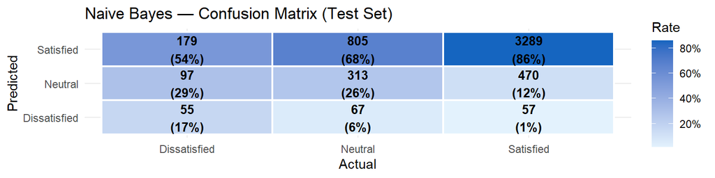

```r
plot_cm(nb_res$confusion_matrix, "Naive Bayes — Confusion Matrix (Test Set)")
```

#### 5.4 Random Forest (RF)

Random Forest aggregates predictions from an ensemble of de-correlated decision trees. Two imbalance strategies are compared: **power-based class weights** (power = 0.75/0.85/0.95) and **downsampling**. The best is selected via 3-fold CV Macro F1. The `extratrees` split rule provides extra randomisation(see Model Improvement for tuning details).

```r
### RF: Best model selected from multiple strategies (pre-computed)
library(ranger)
make_class_weights_rf <- function(y, weight_power = 0.75) {
  cc <- table(y); as.numeric((max(cc) / cc) ^ weight_power)
}
for (wp in c(0.75, 0.85, 0.95)) {
  rf_fit <- train(
    JobSat_Class ~ ., data = train_3, method = "ranger",
    trControl = ctrl_rf, tuneGrid = rf_grid_w, metric = "Macro_F1",
    num.trees = 100, importance = "impurity",
    respect.unordered.factors = "order",
    class.weights = make_class_weights_rf(train_3$JobSat_Class, wp))
}
rf_down <- train(
  JobSat_Class ~ ., data = train_3, method = "ranger",
  trControl = trainControl(method="cv", number=3, sampling="down"),
  tuneGrid = rf_grid_d, metric = "Macro_F1", num.trees = 100)
best_rf <- all_rf_models[[best_rf_id]]
rf_pred_3 <- predict(best_rf, newdata = test_3)
```

**Best parameters:** mtry = 6, min.node.size = 20, strategy = weights_0.95. **Imbalance strategy:** weights_0.95.

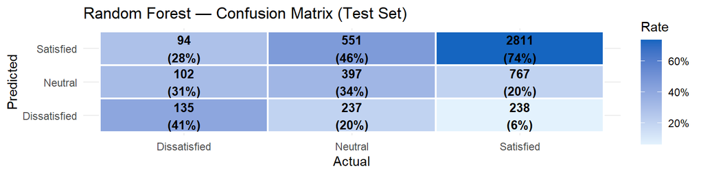

```r
plot_cm(rf_res$confusion_matrix, "Random Forest — Confusion Matrix (Test Set)")
```

#### 5.5 Multinomial Logistic Regression (LR)

Multinomial logistic regression extends binary logistic regression to multiple classes via a softmax link. Features are dummy-encoded (`fullRank = TRUE`) and standardised (center + scale, parameters from training set only). Class imbalance is handled via **power-weighted case weights** (power = 0.75) (see Model Improvement for tuning details).

```r
### LR: Final model with best hyperparameters (pre-computed)
library(nnet)
make_case_weights_lr <- function(y, weight_power = 0.75) {
  cc <- table(y); cw <- (max(cc) / cc) ^ weight_power
  as.numeric(cw[as.character(y)])
}
dummy_lr <- dummyVars(~ ., data = x_train_lr, fullRank = TRUE)
x_train_dummy <- predict(dummy_lr, newdata = x_train_lr) %>% as.data.frame()
x_test_dummy  <- predict(dummy_lr, newdata = x_test_lr) %>% as.data.frame()
nzv_idx <- nearZeroVar(x_train_dummy, saveMetrics = FALSE)
if (length(nzv_idx) > 0) {
  x_train_dummy <- x_train_dummy[, -nzv_idx]; x_test_dummy <- x_test_dummy[, -nzv_idx]
}
set.seed(123)
lr_model_3 <- train(
  x = x_train_dummy, y = y_train_lr, method = "multinom",
  trControl = trainControl(method="cv", number=3, summaryFunction=macro_f1_summary),
  tuneGrid = expand.grid(decay = c(0, 0.001, 0.01, 0.1)),
  metric = "Macro_F1", preProcess = c("center","scale"),
  weights = make_case_weights_lr(y_train_lr, 0.75),
  trace = FALSE, maxit = 300, MaxNWts = 100000)
lr_pred_3 <- predict(lr_model_3, newdata = x_test_dummy)
```

**Best parameters:** decay = 0.1. **Imbalance strategy:** power case weights (0.75).

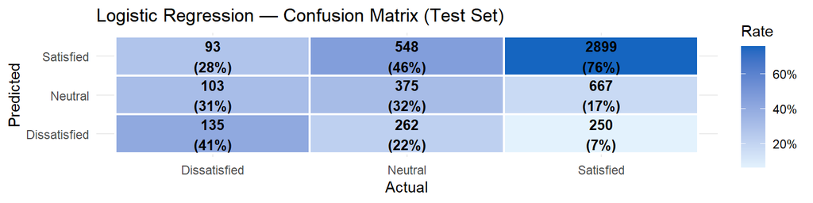

```r
plot_cm(lr_res$confusion_matrix, "Logistic Regression — Confusion Matrix (Test Set)")
```

### 6 Model Improvement

#### 6.1 Feature Selection and Engineering

Starting from 172 raw survey columns, we applied a multi-stage feature selection pipeline. All decisions were based exclusively on training data.

```r
funnel_df <- data.frame(
  Stage = c("Raw survey columns",
            "Domain-relevant candidate selection",
            "After high-missingness removal (>80%)",
            "After multi-response binarisation + LeavingScore",
            "After near-zero variance removal",
            "After high-correlation removal (r > 0.90)",
            "Final feature set used by all models"),
  Features = c(172, 22, "~20", "~50+ (binary expansion)", "varies", "varies",
               ncol(train_3) - 1))
kable(funnel_df, col.names = c("Stage", "Feature Count"), align = "lr") %>%
  kable_styling(bootstrap_options = c("striped","hover","condensed"), full_width = TRUE, font_size = 12)
```

| Stage | Feature Count |
| --- | --- |
| Raw survey columns | 172 |
| Domain-relevant candidate selection | 22 |
| After high-missingness removal (>80%) | ~20 |
| After multi-response binarisation + LeavingScore | ~50+ (binary expansion) |
| After near-zero variance removal | varies |
| After high-correlation removal (r > 0.90) | varies |
| Final feature set used by all models | 24 |

We selected 22 domain-relevant predictors covering demographics (Age, EdLevel, Country), work context (Employment, RemoteWork, OrgSize, ICorPM, DevType, Industry), experience (WorkExp, YearsCode), compensation (ConvertedCompYearly), AI attitudes (AISelect, AISent, AIAcc, AIThreat), career intent (NewRole), and tool usage (ToolCountWork, ToolCountPersonal, TechEndorseIntro, PurchaseInfluence). Feature engineering included: (1) binarising multi-response columns (e.g., DevType, Employment) into top-15 binary indicators, (2) creating a `LeavingScore` ordinal feature by mapping NewRole’s 5 career-change categories to a 0–4 numeric scale, and (3) log-transforming ConvertedCompYearly to normalise its right-skewed distribution. We then applied near-zero variance removal and high-correlation filtering (r > 0.90) to arrive at the final feature set.

#### 6.2 Hyperparameter Tuning

All five models were tuned using **3-fold cross-validation** with **Macro F1** as the primary selection metric. Complete tuning code was executed in advance via `run_all_models.R`; the key tuning logic is shown in foldable blocks below.

```r
### GBM tuning: 24 combos on stratified subset, 3-fold CV
gbm_grid_3 <- expand.grid(
  n.trees = c(500, 800, 1000), interaction.depth = c(3, 5),
  shrinkage = c(0.03, 0.05), n.minobsinnode = c(10, 20))
set.seed(123)
tune_p <- min(1, 12000 / nrow(train_3))
tune_idx <- createDataPartition(train_3$JobSat_Class, p = tune_p, list = FALSE)
tune_data <- train_3[tune_idx, ]
gbm_tuned_3 <- train(
  JobSat_Class ~ ., data = tune_data, method = "gbm",
  trControl = trainControl(method = "cv", number = 3,
    summaryFunction = macro_f1_summary, savePredictions = "final"),
  tuneGrid = gbm_grid_3, metric = "Macro_F1",
  weights = make_class_weights(tune_data$JobSat_Class), verbose = FALSE)
```

```r
### DNN tuning: 8 combos x 3 folds = 24 training runs (manual CV)
dnn_grid <- expand.grid(
  lr = c(0.001, 0.0005), dropout_rate = c(0.3, 0.5),
  hidden_size = c("large", "small"), stringsAsFactors = FALSE)
fold_index_dnn <- createFolds(factor(y_train_dnn, levels = 1:3), k = 3, list = TRUE)
for (i in seq_len(nrow(dnn_grid))) {
  for (k in 1:3) {
    ### Per-fold: train with Focal Loss (gamma=2.0), 80 epochs, early stopping patience=12
    ### Evaluate Macro F1 on validation fold
  }
}
### Select combo with highest mean CV Macro F1
```

```r
### NB tuning: 6 combos, 3-fold CV on SMOTE-balanced training set
tune_grid_nb <- expand.grid(laplace = c(0, 1, 5), usekernel = c(FALSE, TRUE), adjust = 1)
nb_model_3 <- train(
  JobSat_Class ~ ., data = train_bal_nb, method = "naive_bayes",
  trControl = trainControl(method="cv", number=3, classProbs=TRUE,
                           summaryFunction=multiClassSummary),
  tuneGrid = tune_grid_nb, metric = "Mean_F1")
```

```r
### RF tuning: ~60 combos across 4 strategies, 3-fold CV
rf_grid_w <- expand.grid(
  mtry = unique(pmin(ncol(train_3)-1, c(6,8,10,12,16))),
  splitrule = "extratrees", min.node.size = c(10, 15, 20))
for (wp in c(0.75, 0.85, 0.95)) {
  train(JobSat_Class ~ ., data = train_3, method = "ranger",
    trControl = ctrl_rf, tuneGrid = rf_grid_w, metric = "Macro_F1",
    num.trees = 100, class.weights = make_class_weights_rf(train_3$JobSat_Class, wp))
}
train(JobSat_Class ~ ., data = train_3, method = "ranger",
  trControl = trainControl(method="cv", number=3, sampling="down"),
  tuneGrid = rf_grid_d, metric = "Macro_F1", num.trees = 100)
```

```r
### LR tuning: 4 decay values, 3-fold CV
train(x = x_train_dummy, y = y_train_lr, method = "multinom",
  trControl = trainControl(method="cv", number=3, summaryFunction=macro_f1_summary),
  tuneGrid = expand.grid(decay = c(0, 0.001, 0.01, 0.1)),
  metric = "Macro_F1", preProcess = c("center","scale"),
  weights = make_case_weights_lr(y_train_lr, 0.75),
  trace = FALSE, maxit = 300, MaxNWts = 100000)
```

The table below summarises all tuning configurations and results:

```r
tuning_summary <- data.frame(
  Model = c("GBM", "DNN", "Naive Bayes", "Random Forest", "Logistic Regression"),
  Search_Space = c(
    "n.trees={500,800,1000} x depth={3,5} x shrinkage={0.03,0.05} x min.node={10,20}",
    "lr={0.001,0.0005} x dropout={0.3,0.5} x hidden={large(128/64/32),small(64/32/16)}",
    "laplace={0,1,5} x usekernel={TRUE,FALSE}",
    "mtry={6,8,10,12,16} x min.node={10,15,20} x weight_power={0.75,0.85,0.95} + downsample",
    "decay={0,0.001,0.01,0.1}"),
  Combos = c(24, 8, 6, "~60", 4),
  CV = rep("3-fold", 5),
  Imbalance = c("Sqrt case weights", "Focal Loss (gamma=2) + Neutral x1.5",
                "SMOTE (ratio=0.8)", "Power class weights + downsample",
                "Power case weights (0.75)"),
  Best_Params = c(
    paste0("trees=", gbm_res$best_params$n.trees, " depth=", gbm_res$best_params$interaction.depth,
           " lr=", gbm_res$best_params$shrinkage, " node=", gbm_res$best_params$n.minobsinnode),
    paste0("lr=", dnn_res$best_params$lr, " drop=", dnn_res$best_params$dropout,
           " net=", dnn_res$best_params$hidden),
    paste0("laplace=", nb_res$best_params$laplace, " kernel=", nb_res$best_params$usekernel),
    paste0("mtry=", rf_res$best_params$mtry, " node=", rf_res$best_params$min.node.size,
           " ", rf_res$best_params$model_id),
    paste0("decay=", lr_res$best_params$decay)),
  Test_MacroF1 = c(gbm_res$overall_metrics$Macro_F1, dnn_res$overall_metrics$Macro_F1,
                   nb_res$overall_metrics$Macro_F1, rf_res$overall_metrics$Macro_F1,
                   lr_res$overall_metrics$Macro_F1))

kable(tuning_summary,
  col.names = c("Model","Search Space","Combos","CV","Imbalance Strategy","Best Parameters","Test Macro F1"),
  align = "llcclcr") %>%
  kable_styling(bootstrap_options = c("striped","hover","condensed"), full_width = TRUE, font_size = 11) %>%
  column_spec(7, bold = TRUE)
```

| Model | Search Space | Combos | CV | Imbalance Strategy | Best Parameters | Test Macro F1 |
| --- | --- | --- | --- | --- | --- | --- |
| GBM | n.trees={500,800,1000} x depth={3,5} x shrinkage={0.03,0.05} x min.node={10,20} | 24 | 3-fold | Sqrt case weights | trees=500 depth=3 lr=0.03 node=10 | 0.4707 |
| DNN | lr={0.001,0.0005} x dropout={0.3,0.5} x hidden={large(128/64/32),small(64/32/16)} | 8 | 3-fold | Focal Loss (gamma=2) + Neutral x1.5 | lr=5e-04 drop=0.3 net=large | 0.4693 |
| Naive Bayes | laplace={0,1,5} x usekernel={TRUE,FALSE} | 6 | 3-fold | SMOTE (ratio=0.8) | laplace=0 kernel=TRUE | 0.4440 |
| Random Forest | mtry={6,8,10,12,16} x min.node={10,15,20} x weight_power={0.75,0.85,0.95} + downsample | ~60 | 3-fold | Power class weights + downsample | mtry=6 node=20 weights_0.95 | 0.4613 |
| Logistic Regression | decay={0,0.001,0.01,0.1} | 4 | 3-fold | Power case weights (0.75) | decay=0.1 | 0.4621 |

**Key findings:** GBM achieved the highest test Macro F1 (0.4707), benefiting from iterative error correction and native handling of mixed feature types. We effectively alleviated the class imbalance problem by applying the Focal loss function to the DNN model, making it focus on samples that are difficult to classify.DNN performed in test data(0.4693).The Naive Bayes model does not perform well on the test set(0.444).This demonstrates that the features in this dataset are not independent, and also justifies our use of a more complex model to capture non-linear relationships.

*You can view the complete data preprocessing and model training/parameter tuning/evaluation process of our project by expanding the collapsed code block below (`run_all_models.R`), which will allow you to reproduce our experiments.*

```r
# ============================================================
# run_all_models.R
# Unified pipeline: shared preprocessing + 5 models (3-class)
# Saves each model's tuning process and final results as .rds
#
# Usage:
#   1. Place survey_results_public.csv in the working directory
#   2. Create a "results" folder: dir.create("results")
#   3. Run this script section by section, or source() the whole file
#   4. Output: results/gbm_3class.rds, results/dnn_3class.rds, etc.
#
# Note: DNN section requires {torch} and {luz} packages.
#       NB section requires {e1071}, {naivebayes}, {themis}, {recipes}.
#       RF/LR section requires {ranger}, {nnet}.
# ============================================================

dir.create("results", showWarnings = FALSE)

# ############################################################
#
#   PART 0: SHARED PREPROCESSING (DO NOT MODIFY)
#
# ############################################################

library(caret)
library(gbm)
library(tidyverse)
library(forcats)
library(ggplot2)

set.seed(123)

# ============================================================
# 0.1 Load data
# ============================================================

data_path <- "survey_results_public.csv"
df <- read_csv(data_path, show_col_types = FALSE)

# ============================================================
# 0.2 Helper functions
# ============================================================

convert_years <- function(x) {
  x <- as.character(x)
  x[x == "Less than 1 year"] <- "0.5"
  x[x == "More than 50 years"] <- "51"
  as.numeric(x)
}

safe_median <- function(x) {
  med <- median(x, na.rm = TRUE)
  ifelse(is.na(med), 0, med)
}

safe_quantile <- function(x, prob = 0.99) {
  if (all(is.na(x))) return(0)
  q <- quantile(x, probs = prob, na.rm = TRUE)
  ifelse(is.na(q), max(x, na.rm = TRUE), q)
}

safe_remove_vars <- function(data, vars) {
  vars <- vars[!is.na(vars) & vars != "" & vars %in% names(data)]
  if (length(vars) > 0) data <- data %>% select(-any_of(vars))
  data
}

is_near_zero_var <- function(x, freq_cut = 95 / 5, unique_cut = 10) {
  x <- as.character(x)
  x <- x[!is.na(x)]
  if (length(x) == 0) return(TRUE)
  tab <- sort(table(x), decreasing = TRUE)
  if (length(tab) == 1) return(TRUE)
  freq_ratio <- as.numeric(tab[1] / tab[2])
  percent_unique <- length(unique(x)) / length(x) * 100
  freq_ratio > freq_cut && percent_unique < unique_cut
}

# ============================================================
# 0.3 Create target variable and select raw predictors
# ============================================================

gbm_raw <- df %>%
  mutate(
    JobSat = as.numeric(JobSat),
    JobSat_Class = case_when(
      JobSat <= 1  ~ "Very_Dissatisfied",
      JobSat <= 3  ~ "Dissatisfied",
      JobSat <= 6  ~ "Neutral",
      JobSat <= 8  ~ "Satisfied",
      JobSat <= 10 ~ "Very_Satisfied",
      TRUE ~ NA_character_
    ),
    JobSat_Class = factor(JobSat_Class,
      levels = c("Very_Dissatisfied", "Dissatisfied", "Neutral",
                 "Satisfied", "Very_Satisfied")),
    YearsCode = convert_years(YearsCode),
    WorkExp = as.numeric(WorkExp),
    ConvertedCompYearly = as.numeric(ConvertedCompYearly)
  ) %>%
  select(any_of(c(
    "JobSat_Class",
    "Age", "EdLevel", "Employment", "RemoteWork",
    "WorkExp", "YearsCode", "OrgSize", "ICorPM",
    "Country", "DevType", "Industry",
    "AISelect", "AISent", "AIAcc", "AIThreat",
    "NewRole", "TechEndorseIntro", "PurchaseInfluence",
    "ToolCountWork", "ToolCountPersonal",
    "ConvertedCompYearly"
  ))) %>%
  filter(!is.na(JobSat_Class))

# ============================================================
# 0.4 Stratified train-test split BEFORE preprocessing
# ============================================================

train_index <- createDataPartition(gbm_raw$JobSat_Class, p = 0.8, list = FALSE)
train_raw <- gbm_raw[train_index, ]
test_raw  <- gbm_raw[-train_index, ]

# ============================================================
# 0.5 Fit preprocessing rules on training data only
# ============================================================

fit_gbm_preprocess <- function(train_data) {
  missing_rates <- sapply(train_data, function(x) mean(is.na(x)))
  high_missing_vars <- names(missing_rates)[
    missing_rates > 0.80 & names(missing_rates) != "JobSat_Class"]
  high_missing_vars <- high_missing_vars[!is.na(high_missing_vars) & high_missing_vars != ""]
  train_data_reduced <- safe_remove_vars(train_data, high_missing_vars)

  numeric_vars <- intersect(
    c("WorkExp", "YearsCode", "ToolCountWork", "ToolCountPersonal"),
    names(train_data_reduced))
  numeric_medians <- list()
  for (v in numeric_vars) numeric_medians[[v]] <- safe_median(train_data_reduced[[v]])

  workexp_cap <- if ("WorkExp" %in% names(train_data_reduced))
    safe_quantile(train_data_reduced$WorkExp, 0.99) else NA
  yearscode_cap <- if ("YearsCode" %in% names(train_data_reduced))
    safe_quantile(train_data_reduced$YearsCode, 0.99) else NA
  salary_cap <- if ("ConvertedCompYearly" %in% names(train_data_reduced))
    safe_quantile(train_data_reduced$ConvertedCompYearly, 0.99) else NA

  if ("ConvertedCompYearly" %in% names(train_data_reduced)) {
    salary_temp <- train_data_reduced$ConvertedCompYearly
    salary_temp[salary_temp < 0] <- NA
    salary_temp <- ifelse(salary_temp > salary_cap, salary_cap, salary_temp)
    log_salary_median <- safe_median(log1p(salary_temp))
  } else {
    log_salary_median <- 0
  }

  multi_response_candidates <- intersect(
    c("DevType", "Employment", "AISelect", "AISent", "AIAcc", "AIThreat",
      "NewRole", "TechEndorseIntro", "PurchaseInfluence"),
    names(train_data_reduced))
  multi_response_vars  <- c()
  multi_response_terms <- list()
  for (v in multi_response_candidates) {
    x <- as.character(train_data_reduced[[v]])
    if (any(str_detect(x[!is.na(x)], fixed(";")))) {
      multi_response_vars <- c(multi_response_vars, v)
      split_values <- trimws(unlist(strsplit(x[!is.na(x)], ";", fixed = TRUE)))
      split_values <- split_values[split_values != ""]
      value_counts <- sort(table(split_values), decreasing = TRUE)
      multi_response_terms[[v]] <- names(value_counts)[1:min(15, length(value_counts))]
    }
  }
```

```r
  categorical_vars <- setdiff(
    intersect(
      c("Age", "EdLevel", "RemoteWork", "OrgSize", "ICorPM", "Country", "Industry",
        "AISelect", "AISent", "AIAcc", "AIThreat", "Employment", "DevType",
        "NewRole", "TechEndorseIntro", "PurchaseInfluence"),
      names(train_data_reduced)),
    multi_response_vars)
  top_levels <- list()
  for (v in categorical_vars) {
    x <- as.character(train_data_reduced[[v]])
    x[is.na(x)] <- "Missing"
    level_counts <- sort(table(x), decreasing = TRUE)
    top_levels[[v]] <- names(level_counts)[1:min(15, length(level_counts))]
  }

  list(
    high_missing_vars = high_missing_vars,
    numeric_vars = numeric_vars, numeric_medians = numeric_medians,
    workexp_cap = workexp_cap, yearscode_cap = yearscode_cap,
    salary_cap = salary_cap, log_salary_median = log_salary_median,
    categorical_vars = categorical_vars, top_levels = top_levels,
    multi_response_vars = multi_response_vars, multi_response_terms = multi_response_terms
  )
}

# ============================================================
# 0.6 Apply preprocessing rules
# ============================================================

apply_gbm_preprocess <- function(data, prep) {
  data <- safe_remove_vars(data, prep$high_missing_vars)

  if ("WorkExp"             %in% names(data)) data$Missing_WorkExp             <- ifelse(is.na(data$WorkExp), 1, 0)
  if ("YearsCode"           %in% names(data)) data$Missing_YearsCode           <- ifelse(is.na(data$YearsCode), 1, 0)
  if ("ConvertedCompYearly" %in% names(data)) data$Missing_ConvertedCompYearly <- ifelse(is.na(data$ConvertedCompYearly), 1, 0)
  if ("OrgSize"             %in% names(data)) data$Missing_OrgSize             <- ifelse(is.na(data$OrgSize), 1, 0)

  if ("WorkExp" %in% names(data)) {
    data$WorkExp[data$WorkExp < 0] <- NA
    data$WorkExp <- ifelse(!is.na(data$WorkExp) & data$WorkExp > prep$workexp_cap,
                           prep$workexp_cap, data$WorkExp)
    data$WorkExp[is.na(data$WorkExp)] <- prep$numeric_medians[["WorkExp"]]
  }
  if ("YearsCode" %in% names(data)) {
    data$YearsCode[data$YearsCode < 0] <- NA
    data$YearsCode <- ifelse(!is.na(data$YearsCode) & data$YearsCode > prep$yearscode_cap,
                             prep$yearscode_cap, data$YearsCode)
    data$YearsCode[is.na(data$YearsCode)] <- prep$numeric_medians[["YearsCode"]]
  }
  for (v in setdiff(prep$numeric_vars, c("WorkExp", "YearsCode"))) {
    if (v %in% names(data)) data[[v]][is.na(data[[v]])] <- prep$numeric_medians[[v]]
  }

  if ("ConvertedCompYearly" %in% names(data)) {
    data$ConvertedCompYearly[data$ConvertedCompYearly < 0] <- NA
    data$ConvertedCompYearly <- ifelse(
      !is.na(data$ConvertedCompYearly) & data$ConvertedCompYearly > prep$salary_cap,
      prep$salary_cap, data$ConvertedCompYearly)
    data$LogConvertedCompYearly <- log1p(data$ConvertedCompYearly)
    data$LogConvertedCompYearly[is.na(data$LogConvertedCompYearly)] <- prep$log_salary_median
    data$ConvertedCompYearly <- NULL
  }

  for (v in prep$categorical_vars) {
    if (v %in% names(data)) {
      x <- as.character(data[[v]])
      x[is.na(x)] <- "Missing"
      x[!(x %in% prep$top_levels[[v]])] <- "Other"
      data[[v]] <- factor(x, levels = unique(c(prep$top_levels[[v]], "Other", "Missing")))
    }
  }

  for (v in prep$multi_response_vars) {
    if (v %in% names(data)) {
      raw_x <- as.character(data[[v]])
      raw_x[is.na(raw_x)] <- ""
      padded_x <- paste0(";", raw_x, ";")
      for (term in prep$multi_response_terms[[v]]) {
        data[[paste0(v, "_", make.names(term))]] <-
          ifelse(str_detect(padded_x, fixed(paste0(";", term, ";"))), 1, 0)
      }
      data[[v]] <- NULL
    }
  }
  data
}

# ============================================================
# 0.7 Fit and apply preprocessing
# ============================================================

gbm_prep   <- fit_gbm_preprocess(train_raw)
train_data <- apply_gbm_preprocess(train_raw, gbm_prep)
test_data  <- apply_gbm_preprocess(test_raw,  gbm_prep)

levels_order <- c("Very_Dissatisfied", "Dissatisfied", "Neutral", "Satisfied", "Very_Satisfied")
train_data$JobSat_Class <- factor(train_data$JobSat_Class, levels = levels_order)
test_data$JobSat_Class  <- factor(test_data$JobSat_Class,  levels = levels_order)

# ============================================================
# 0.8 Derived feature: LeavingScore (ordinal encoding of NewRole)
# ============================================================

leaving_map <- c(
  "I have strongly considered changing my career and/or the industry I work in" = 4,
  "I have somewhat considered changing my career and/or the industry I work in" = 3,
  "I have transitioned into a new career and/or industry involuntarily"         = 2,
  "I have neither consider or transitioned into a new career or industry"       = 1,
  "I have transitioned into a new career and/or industry voluntarily"           = 0
)

add_leaving_score <- function(data, median_value) {
  if ("NewRole" %in% names(data)) {
    nr_char <- as.character(data$NewRole)
    data$LeavingScore <- leaving_map[nr_char]
    data$LeavingScore[is.na(data$LeavingScore)] <- median_value
  }
  data
}

train_leaving_raw <- leaving_map[as.character(train_data$NewRole)]
leaving_median <- median(train_leaving_raw, na.rm = TRUE)

train_data <- add_leaving_score(train_data, leaving_median)
test_data  <- add_leaving_score(test_data,  leaving_median)

cat("LeavingScore added. Training median:", leaving_median, "\n")

# ============================================================
# 0.9 Feature selection based on training data only
# ============================================================

predictor_names <- setdiff(names(train_data), "JobSat_Class")
nzv_vars <- predictor_names[sapply(train_data[predictor_names], is_near_zero_var)]
nzv_vars <- nzv_vars[!is.na(nzv_vars) & nzv_vars != "" & nzv_vars %in% names(train_data)]
train_data <- safe_remove_vars(train_data, nzv_vars)
test_data  <- safe_remove_vars(test_data,  nzv_vars)
```

```r
numeric_predictors <- names(train_data)[
  sapply(train_data, is.numeric) & names(train_data) != "JobSat_Class"]
numeric_predictors <- numeric_predictors[
  !is.na(numeric_predictors) & numeric_predictors != "" &
    numeric_predictors %in% names(train_data)]
numeric_predictors <- numeric_predictors[
  sapply(train_data[numeric_predictors], function(x) sd(x, na.rm = TRUE) > 0)]

high_corr_vars <- character(0)
if (length(numeric_predictors) > 1) {
  corr_matrix <- cor(train_data[numeric_predictors], use = "pairwise.complete.obs")
  corr_matrix[is.na(corr_matrix)] <- 0
  high_corr_index <- findCorrelation(corr_matrix, cutoff = 0.90, names = FALSE)
  if (length(high_corr_index) > 0) high_corr_vars <- numeric_predictors[high_corr_index]
}
high_corr_vars <- high_corr_vars[
  !is.na(high_corr_vars) & high_corr_vars != "" & high_corr_vars %in% names(train_data)]
train_data <- safe_remove_vars(train_data, high_corr_vars)
test_data  <- safe_remove_vars(test_data,  high_corr_vars)

removed_variables <- list(
  high_missing_vars       = gbm_prep$high_missing_vars,
  near_zero_variance_vars = nzv_vars,
  high_correlation_vars   = high_corr_vars
)

cat("\n===== Preprocessing complete =====\n")
cat("Training set:", nrow(train_data), "rows x", ncol(train_data), "cols\n")
cat("Test set:    ", nrow(test_data),  "rows x", ncol(test_data),  "cols\n")
cat("Removed vars:\n"); print(removed_variables)

# ============================================================
# 0.10 Build 3-class datasets (all 5 models use this)
#
# Mapping:
#   Dissatisfied = Very_Dissatisfied + Dissatisfied
#   Neutral      = Neutral
#   Satisfied    = Satisfied + Very_Satisfied
# ============================================================

remap_to_3class <- function(x) {
  factor(
    case_when(
      x %in% c("Very_Dissatisfied", "Dissatisfied") ~ "Dissatisfied",
      x == "Neutral"                                ~ "Neutral",
      x %in% c("Satisfied", "Very_Satisfied")       ~ "Satisfied",
      TRUE ~ NA_character_
    ),
    levels = c("Dissatisfied", "Neutral", "Satisfied")
  )
}

train_3 <- train_data
test_3  <- test_data
train_3$JobSat_Class <- remap_to_3class(train_data$JobSat_Class)
test_3$JobSat_Class  <- remap_to_3class(test_data$JobSat_Class)

cat("\n===== 3-Class Distribution =====\n")
cat("Train:\n"); print(table(train_3$JobSat_Class))
cat("Test:\n");  print(table(test_3$JobSat_Class))

# ============================================================
# 0.11 Unified evaluation function (used by ALL models)
# ============================================================

unified_evaluate <- function(pred, obs, model_name) {
  lev <- levels(obs)
  pred <- factor(pred, levels = lev)
  obs  <- factor(obs,  levels = lev)

  cm <- confusionMatrix(data = pred, reference = obs)
  cm_tab <- table(Actual = obs, Predicted = pred)

  # Per-class metrics
  class_metrics <- data.frame(
    Class     = lev,
    Precision = NA_real_,
    Recall    = NA_real_,
    F1        = NA_real_,
    Support   = NA_integer_
  )

  for (i in seq_along(lev)) {
    cn <- lev[i]
    TP <- cm_tab[cn, cn]
    FP <- sum(cm_tab[, cn]) - TP
    FN <- sum(cm_tab[cn, ]) - TP

    prec <- ifelse((TP + FP) == 0, 0, TP / (TP + FP))
    rec  <- ifelse((TP + FN) == 0, 0, TP / (TP + FN))
    f1   <- ifelse((prec + rec) == 0, 0, 2 * prec * rec / (prec + rec))

    class_metrics$Precision[i] <- round(prec, 4)
    class_metrics$Recall[i]    <- round(rec, 4)
    class_metrics$F1[i]        <- round(f1, 4)
    class_metrics$Support[i]   <- as.integer(sum(cm_tab[cn, ]))
  }

  # Overall metrics
  overall_metrics <- data.frame(
    Model           = model_name,
    Accuracy        = round(as.numeric(cm$overall["Accuracy"]), 4),
    Kappa           = round(as.numeric(cm$overall["Kappa"]), 4),
    Macro_F1        = round(mean(class_metrics$F1), 4),
    Weighted_F1     = round(weighted.mean(class_metrics$F1, class_metrics$Support), 4),
    Macro_Precision = round(mean(class_metrics$Precision), 4),
    Macro_Recall    = round(mean(class_metrics$Recall), 4)
  )

  list(
    confusion_matrix = cm,
    class_metrics    = class_metrics,
    overall_metrics  = overall_metrics
  )
}

# ============================================================
# Shared macro F1 summary function for caret CV
# ============================================================

macro_f1_summary <- function(data, lev = NULL, model = NULL) {
  obs  <- factor(data$obs,  levels = lev)
  pred <- factor(data$pred, levels = lev)
  cm <- table(obs, pred)
  f1_scores <- sapply(lev, function(cn) {
    TP <- cm[cn, cn]
    FP <- sum(cm[, cn]) - TP
    FN <- sum(cm[cn, ]) - TP
    prec <- ifelse((TP + FP) == 0, 0, TP / (TP + FP))
    rec  <- ifelse((TP + FN) == 0, 0, TP / (TP + FN))
    ifelse((prec + rec) == 0, 0, 2 * prec * rec / (prec + rec))
  })
  c(Macro_F1 = mean(f1_scores), Accuracy = mean(obs == pred))
}

# ============================================================
# Shared class weight function (sqrt weighting)
# ============================================================

make_class_weights <- function(y) {
  y <- factor(y)
  cc <- table(y)
  raw_w <- sqrt(max(cc) / cc)
  w <- raw_w[as.character(y)]
  as.numeric(w)
}


# ############################################################
#
#   MODEL 1: GRADIENT BOOSTING (GBM)
#
# ############################################################

cat("\n\n========== MODEL 1: GBM (3-Class) ==========\n")

# --- Parallel backend ---
use_parallel <- FALSE
cl_par <- NULL
if (requireNamespace("doParallel", quietly = TRUE)) {
  avail <- parallel::detectCores()
  if (!is.na(avail) && avail > 1) {
    cl_par <- parallel::makeCluster(max(1, avail - 1))
    doParallel::registerDoParallel(cl_par)
    use_parallel <- TRUE
    cat("Parallel backend:", max(1, avail - 1), "cores\n")
  }
}

# --- CV control ---
ctrl_tune_gbm <- trainControl(
  method = "cv", number = 3,
  summaryFunction = macro_f1_summary,
  classProbs = FALSE, sampling = NULL,
  savePredictions = "final", allowParallel = use_parallel
)
```

```r
ctrl_final_gbm <- trainControl(
  method = "none", classProbs = FALSE,
  sampling = NULL, allowParallel = use_parallel
)

# --- Tuning grid (same as original GBM 3-class code) ---
gbm_grid_3 <- expand.grid(
  n.trees           = c(500, 800, 1000),
  interaction.depth = c(3, 5),
  shrinkage         = c(0.03, 0.05),
  n.minobsinnode    = c(10, 20)
)

cat("GBM grid: ", nrow(gbm_grid_3), " combinations\n")

# --- Tuning on subset (as in original code) ---
set.seed(123)
tune_p_3     <- min(1, 12000 / nrow(train_3))
tune_index_3 <- createDataPartition(train_3$JobSat_Class, p = tune_p_3, list = FALSE)
tune_data_3  <- train_3[tune_index_3, ]
tune_weights_3 <- make_class_weights(tune_data_3$JobSat_Class)

set.seed(123)
gbm_tuned_3 <- train(
  JobSat_Class ~ ., data = tune_data_3,
  method = "gbm", trControl = ctrl_tune_gbm,
  tuneGrid = gbm_grid_3, metric = "Macro_F1",
  weights = tune_weights_3, verbose = FALSE
)

best_grid_gbm <- gbm_tuned_3$bestTune
cat("GBM best params:\n"); print(best_grid_gbm)

# --- Final model on full training set ---
final_weights_3 <- make_class_weights(train_3$JobSat_Class)

set.seed(123)
gbm_final_3 <- train(
  JobSat_Class ~ ., data = train_3,
  method = "gbm", trControl = ctrl_final_gbm,
  tuneGrid = best_grid_gbm,
  weights = final_weights_3, verbose = FALSE
)

# --- Evaluate ---
gbm_pred_3 <- predict(gbm_final_3, newdata = test_3)
gbm_eval_3 <- unified_evaluate(gbm_pred_3, test_3$JobSat_Class, "GBM")

cat("\n>>> GBM 3-Class Results\n")
print(gbm_eval_3$overall_metrics)
print(gbm_eval_3$class_metrics)

# --- Variable importance ---
gbm_varimp <- varImp(gbm_final_3)

# --- Save ---
saveRDS(list(
  model_name     = "Gradient Boosting (GBM)",
  tuning_grid    = gbm_grid_3,
  tuning_results = gbm_tuned_3$results,
  best_params    = best_grid_gbm,
  overall_metrics = gbm_eval_3$overall_metrics,
  class_metrics   = gbm_eval_3$class_metrics,
  confusion_matrix = gbm_eval_3$confusion_matrix,
  variable_importance = gbm_varimp
), file = "results/gbm_3class.rds")

cat("Saved: results/gbm_3class.rds\n")

# --- Stop parallel ---
if (!is.null(cl_par)) {
  parallel::stopCluster(cl_par)
  if (requireNamespace("foreach", quietly = TRUE)) foreach::registerDoSEQ()
  cl_par <- NULL
  cat("Parallel backend stopped.\n")
}


# ############################################################
#
#   MODEL 2: DNN (Deep Neural Network)
#
# ############################################################

cat("\n\n========== MODEL 2: DNN (3-Class) ==========\n")

library(torch)
library(luz)

# --- Device ---
if (cuda_is_available()) {
  device <- torch_device("cuda")
  cat("GPU detected.\n")
} else {
  device <- torch_device("cpu")
  cat("Using CPU.\n")
}

# --- 3-class labels (unified: Dissatisfied / Neutral / Satisfied) ---
dnn_label_levels <- c("Dissatisfied", "Neutral", "Satisfied")

# Map from 5-class to 3-class integer labels (1-based for torch)
remap_to_3class_int <- function(x) {
  x_char <- as.character(x)
  x_new <- case_when(
    x_char %in% c("Very_Dissatisfied", "Dissatisfied") ~ 1L,
    x_char == "Neutral"                                 ~ 2L,
    x_char %in% c("Satisfied", "Very_Satisfied")        ~ 3L
  )
  x_new
}

y_train_dnn <- remap_to_3class_int(train_data$JobSat_Class)
y_test_dnn  <- remap_to_3class_int(test_data$JobSat_Class)

# --- One-hot encoding + Z-score standardization ---
X_train_raw <- train_data %>% select(-JobSat_Class)
X_test_raw  <- test_data  %>% select(-JobSat_Class)

X_train_raw$.__split__ <- "train"
X_test_raw$.__split__  <- "test"
combined <- bind_rows(X_train_raw, X_test_raw) %>%
  mutate(across(where(is.character), as.factor))
split_col <- combined$.__split__
combined$.__split__ <- NULL
X_onehot   <- model.matrix(~ . - 1, data = combined)
X_train_oh <- X_onehot[split_col == "train", ]
X_test_oh  <- X_onehot[split_col == "test",  ]

train_means <- apply(X_train_oh, 2, mean)
train_sds   <- apply(X_train_oh, 2, sd)
train_sds[train_sds == 0] <- 1

X_train_scaled <- scale(X_train_oh, center = train_means, scale = train_sds)
X_test_scaled  <- scale(X_test_oh,  center = train_means, scale = train_sds)

# Clip to [-5, 5]
X_train_scaled <- pmax(pmin(X_train_scaled, 5), -5)
X_test_scaled  <- pmax(pmin(X_test_scaled,  5), -5)

X_train_mat <- as.matrix(X_train_scaled)
X_test_mat  <- as.matrix(X_test_scaled)

n_features <- ncol(X_train_mat)
n_classes_dnn <- 3

cat("DNN features after one-hot:", n_features, "\n")

# --- Model architecture ---
dnn_model <- nn_module(
  classname = "JobSatDNN",
  initialize = function(n_features, n_classes,
                        hidden1 = 128, hidden2 = 64, hidden3 = 32,
                        dropout_rate = 0.4) {
    self$fc1     <- nn_linear(n_features, hidden1)
    self$fc2     <- nn_linear(hidden1,    hidden2)
    self$fc3     <- nn_linear(hidden2,    hidden3)
    self$fc4     <- nn_linear(hidden3,    n_classes)
    self$dropout <- nn_dropout(p = dropout_rate)
  },
  forward = function(x) {
    x <- self$dropout(nnf_relu(self$fc1(x)))
    x <- self$dropout(nnf_relu(self$fc2(x)))
    x <- self$dropout(nnf_relu(self$fc3(x)))
    self$fc4(x)
  }
)

# --- Focal Loss ---
focal_loss_module <- nn_module(
  classname = "FocalLoss",
  initialize = function(weight = NULL, gamma = 2.0) {
    self$gamma  <- gamma
    self$weight <- weight
  },
  forward = function(input, target) {
    log_probs <- nnf_log_softmax(input, dim = 2)
    log_pt    <- log_probs$gather(2, target$unsqueeze(2))$squeeze(2)
    pt        <- log_pt$exp()
    focal_w   <- (1 - pt)^self$gamma
    loss      <- -log_pt * focal_w
    if (!is.null(self$weight)) {
      alpha_t <- self$weight[target]
      loss    <- alpha_t * loss
    }
    loss$mean()
  }
)

# --- Class weights (sqrt + Neutral x1.5 boost) ---
dnn_counts   <- table(factor(y_train_dnn, levels = 1:3))
dnn_weights  <- as.numeric(sqrt(length(y_train_dnn) / (n_classes_dnn * dnn_counts)))
dnn_weights  <- dnn_weights / sum(dnn_weights) * n_classes_dnn
dnn_weights[2] <- dnn_weights[2] * 1.5  # Neutral boost
dnn_weights  <- dnn_weights / sum(dnn_weights) * n_classes_dnn
names(dnn_weights) <- dnn_label_levels
class_weights_tensor <- torch_tensor(dnn_weights, dtype = torch_float())$to(device = device)
```

```r
cat("DNN class weights:", round(dnn_weights, 3), "\n")

# --- Helper functions ---
get_hidden_dims <- function(hidden_size) {
  if (hidden_size == "large") list(h1 = 128, h2 = 64, h3 = 32)
  else                        list(h1 = 64,  h2 = 32, h3 = 16)
}

predict_classes_dnn <- function(model, X_mat, device) {
  model$eval()
  with_no_grad({
    X_tensor <- torch_tensor(X_mat, dtype = torch_float())$to(device = device)
    logits   <- model(X_tensor)
    as.integer(torch_argmax(logits, dim = 2)$cpu())
  })
}

# --- Grid search: 2x2x2 = 8 combos, 3-fold CV ---
set.seed(123)
torch_manual_seed(123)

dnn_grid <- expand.grid(
  lr           = c(0.001, 0.0005),
  dropout_rate = c(0.3, 0.5),
  hidden_size  = c("large", "small"),
  stringsAsFactors = FALSE
)

n_folds_dnn <- 3
fold_index_dnn <- createFolds(factor(y_train_dnn, levels = 1:3),
                              k = n_folds_dnn, list = TRUE)

cat("DNN grid search:", nrow(dnn_grid), "combos x", n_folds_dnn, "folds\n\n")

dnn_grid_results <- vector("list", nrow(dnn_grid))

for (i in seq_len(nrow(dnn_grid))) {
  lr           <- dnn_grid$lr[i]
  dropout_rate <- dnn_grid$dropout_rate[i]
  hidden_size  <- dnn_grid$hidden_size[i]
  dims         <- get_hidden_dims(hidden_size)

  cat(sprintf(">>> DNN combo %d/%d | lr=%.4f | dropout=%.1f | hidden=%s\n",
              i, nrow(dnn_grid), lr, dropout_rate, hidden_size))

  fold_mf1 <- numeric(n_folds_dnn)

  for (k in seq_len(n_folds_dnn)) {
    val_idx   <- fold_index_dnn[[k]]
    train_idx <- setdiff(seq_len(nrow(X_train_mat)), val_idx)

    X_cv_train <- X_train_mat[train_idx, ]
    y_cv_train <- y_train_dnn[train_idx]
    X_cv_val   <- X_train_mat[val_idx, ]
    y_cv_val   <- y_train_dnn[val_idx]

    # Per-fold class weights
    cv_counts  <- table(factor(y_cv_train, levels = 1:3))
    cv_w <- as.numeric(sqrt(length(y_cv_train) / (n_classes_dnn * cv_counts)))
    cv_w <- cv_w / sum(cv_w) * n_classes_dnn
    cv_w[2] <- cv_w[2] * 1.5
    cv_w <- cv_w / sum(cv_w) * n_classes_dnn
    cv_wt <- torch_tensor(cv_w, dtype = torch_float())$to(device = device)

    make_ds <- dataset(
      name = "CVDataset",
      initialize = function(X, y) {
        self$X <- torch_tensor(X, dtype = torch_float())
        self$y <- torch_tensor(y, dtype = torch_long())
      },
      .getitem = function(i) list(x = self$X[i, ], y = self$y[i]),
      .length  = function()  nrow(self$X)
    )

    cv_train_dl <- dataloader(make_ds(X_cv_train, y_cv_train),
                              batch_size = 256, shuffle = TRUE)
    cv_val_dl   <- dataloader(make_ds(X_cv_val, y_cv_val),
                              batch_size = 256, shuffle = FALSE)

    cv_focal <- focal_loss_module(weight = cv_wt, gamma = 2.0)

    fitted_cv <- tryCatch({
      dnn_model %>%
        setup(loss = cv_focal, optimizer = optim_adam,
              metrics = list(luz_metric_accuracy())) %>%
        set_hparams(n_features = n_features, n_classes = n_classes_dnn,
                    hidden1 = dims$h1, hidden2 = dims$h2, hidden3 = dims$h3,
                    dropout_rate = dropout_rate) %>%
        set_opt_hparams(lr = lr, weight_decay = 1e-4) %>%
        fit(data = cv_train_dl, epochs = 80, valid_data = cv_val_dl,
            accelerator = accelerator(device_placement = TRUE,
                                      cpu = !cuda_is_available()),
            callbacks = list(luz_callback_early_stopping(patience = 12)))
    }, error = function(e) {
      cat(sprintf("    Fold %d failed: %s\n", k, conditionMessage(e)))
      NULL
    })

    if (is.null(fitted_cv)) { fold_mf1[k] <- NA; next }

    y_cv_pred <- predict_classes_dnn(fitted_cv$model, X_cv_val, device)
    # Compute macro F1 manually
    pred_f <- factor(dnn_label_levels[y_cv_pred], levels = dnn_label_levels)
    true_f <- factor(dnn_label_levels[y_cv_val],  levels = dnn_label_levels)
    cm_cv  <- table(true_f, pred_f)
    f1s <- sapply(dnn_label_levels, function(cn) {
      TP <- cm_cv[cn, cn]; FP <- sum(cm_cv[, cn]) - TP; FN <- sum(cm_cv[cn, ]) - TP
      p <- ifelse((TP+FP)==0, 0, TP/(TP+FP)); r <- ifelse((TP+FN)==0, 0, TP/(TP+FN))
      ifelse((p+r)==0, 0, 2*p*r/(p+r))
    })
    fold_mf1[k] <- mean(f1s)

    cat(sprintf("    Fold %d | Macro F1 = %.4f\n", k, fold_mf1[k]))
  }

  dnn_grid_results[[i]] <- list(
    lr = lr, dropout_rate = dropout_rate, hidden_size = hidden_size,
    cv_mf1_mean = mean(fold_mf1, na.rm = TRUE),
    cv_mf1_sd   = sd(fold_mf1, na.rm = TRUE),
    fold_mf1    = fold_mf1
  )
  cat(sprintf("    CV Macro F1: %.4f +/- %.4f\n\n",
              dnn_grid_results[[i]]$cv_mf1_mean,
              dnn_grid_results[[i]]$cv_mf1_sd))
}

# --- DNN tuning results table ---
dnn_tuning_df <- do.call(rbind, lapply(dnn_grid_results, function(r) {
  data.frame(lr = r$lr, dropout = r$dropout_rate, hidden = r$hidden_size,
             CV_Macro_F1 = round(r$cv_mf1_mean, 4),
             CV_Macro_F1_SD = round(r$cv_mf1_sd, 4))
}))
dnn_tuning_df <- dnn_tuning_df[order(-dnn_tuning_df$CV_Macro_F1), ]
cat("DNN grid results:\n"); print(dnn_tuning_df, row.names = FALSE)

best_dnn_idx <- which.max(sapply(dnn_grid_results, function(r) r$cv_mf1_mean))
best_dnn     <- dnn_grid_results[[best_dnn_idx]]

cat(sprintf("\nDNN best: lr=%.4f | dropout=%.1f | hidden=%s\n",
            best_dnn$lr, best_dnn$dropout_rate, best_dnn$hidden_size))

# --- Train final DNN model ---
best_dnn_dims <- get_hidden_dims(best_dnn$hidden_size)

jobsat_ds <- dataset(
  name = "JobSatFull",
  initialize = function(X, y) {
    self$X <- torch_tensor(X, dtype = torch_float())
    self$y <- torch_tensor(y, dtype = torch_long())
  },
  .getitem = function(i) list(x = self$X[i, ], y = self$y[i]),
  .length  = function()  nrow(self$X)
)

final_train_dl <- dataloader(jobsat_ds(X_train_mat, y_train_dnn),
                             batch_size = 256, shuffle = TRUE)
final_test_dl  <- dataloader(jobsat_ds(X_test_mat,  y_test_dnn),
                             batch_size = 256, shuffle = FALSE)

set.seed(123); torch_manual_seed(123)
final_focal <- focal_loss_module(weight = class_weights_tensor, gamma = 2.0)
```

```r
dnn_final_model <- dnn_model %>%
  setup(loss = final_focal, optimizer = optim_adam,
        metrics = list(luz_metric_accuracy())) %>%
  set_hparams(n_features = n_features, n_classes = n_classes_dnn,
              hidden1 = best_dnn_dims$h1, hidden2 = best_dnn_dims$h2,
              hidden3 = best_dnn_dims$h3, dropout_rate = best_dnn$dropout_rate) %>%
  set_opt_hparams(lr = best_dnn$lr, weight_decay = 1e-4) %>%
  fit(data = final_train_dl, epochs = 80, valid_data = final_test_dl,
      accelerator = accelerator(device_placement = TRUE,
                                cpu = !cuda_is_available()),
      callbacks = list(
        luz_callback_lr_scheduler(torch::lr_reduce_on_plateau, patience = 5, factor = 0.5),
        luz_callback_early_stopping(patience = 15)),
      verbose = TRUE)

cat("\nDNN final model trained.\n")

# --- Evaluate ---
y_pred_dnn <- predict_classes_dnn(dnn_final_model$model, X_test_mat, device)
# Convert integer predictions to factor with unified labels
pred_factor_dnn <- factor(dnn_label_levels[y_pred_dnn], levels = dnn_label_levels)
obs_factor_dnn  <- factor(dnn_label_levels[y_test_dnn], levels = dnn_label_levels)

dnn_eval_3 <- unified_evaluate(pred_factor_dnn, obs_factor_dnn, "DNN")

cat("\n>>> DNN 3-Class Results\n")
print(dnn_eval_3$overall_metrics)
print(dnn_eval_3$class_metrics)

# --- Training history ---
dnn_history <- dnn_final_model$records$metrics
dnn_epochs  <- length(dnn_history$train)
dnn_history_df <- data.frame(
  epoch      = 1:dnn_epochs,
  train_loss = sapply(dnn_history$train, function(x) x$loss),
  valid_loss = sapply(dnn_history$valid, function(x) x$loss),
  train_acc  = sapply(dnn_history$train, function(x) x$acc),
  valid_acc  = sapply(dnn_history$valid, function(x) x$acc)
)

# --- Save (note: torch model objects may not serialize well with saveRDS,
#     so we save metrics/results only, not the model object itself) ---
saveRDS(list(
  model_name       = "Deep Neural Network (DNN)",
  tuning_grid      = dnn_grid,
  tuning_results   = dnn_tuning_df,
  best_params      = data.frame(lr = best_dnn$lr,
                                dropout = best_dnn$dropout_rate,
                                hidden = best_dnn$hidden_size),
  overall_metrics  = dnn_eval_3$overall_metrics,
  class_metrics    = dnn_eval_3$class_metrics,
  confusion_matrix = dnn_eval_3$confusion_matrix,
  training_history = dnn_history_df,
  grid_results_raw = dnn_grid_results
), file = "results/dnn_3class.rds")

cat("Saved: results/dnn_3class.rds\n")


# ############################################################
#
#   MODEL 3: NAIVE BAYES
#
#   IMPORTANT FIX: Uses shared train_3/test_3 (not re-split).
#   Uses SMOTE + 3-fold CV tuning of laplace/usekernel.
#
# ############################################################

cat("\n\n========== MODEL 3: Naive Bayes (3-Class) ==========\n")

library(e1071)
library(recipes)
library(themis)

# --- Prepare NB data from shared train_3/test_3 ---
# Convert all factors to numeric for SMOTE, keep JobSat_Class as factor
train_nb <- train_3
test_nb  <- test_3

# Identify factor columns (excluding target)
factor_cols_nb <- names(train_nb)[sapply(train_nb, is.factor)]
factor_cols_nb <- setdiff(factor_cols_nb, "JobSat_Class")

# Convert factors to numeric for SMOTE
train_nb[factor_cols_nb] <- lapply(train_nb[factor_cols_nb], as.numeric)
test_nb[factor_cols_nb]  <- lapply(test_nb[factor_cols_nb],  as.numeric)

cat("NB pre-SMOTE class distribution:\n")
print(table(train_nb$JobSat_Class))

# --- SMOTE oversampling (over_ratio=0.8 as in original NB 3-class code) ---
rec_nb <- recipe(JobSat_Class ~ ., data = train_nb) %>%
  step_smote(JobSat_Class, over_ratio = 0.8, seed = 123)
rec_prep_nb   <- prep(rec_nb, training = train_nb)
train_bal_nb  <- bake(rec_prep_nb, new_data = NULL)

cat("NB post-SMOTE class distribution:\n")
print(table(train_bal_nb$JobSat_Class))

# --- CV tuning ---
if (requireNamespace("doParallel", quietly = TRUE)) {
  cl_nb <- parallel::makeCluster(max(1, parallel::detectCores() - 1))
  doParallel::registerDoParallel(cl_nb)
} else {
  cl_nb <- NULL
}

ctrl_nb <- trainControl(
  method = "cv", number = 3,
  classProbs = TRUE,
  summaryFunction = multiClassSummary
)

tune_grid_nb <- expand.grid(
  laplace   = c(0, 1, 5),
  usekernel = c(FALSE, TRUE),
  adjust    = 1
)

set.seed(123)
nb_model_3 <- train(
  JobSat_Class ~ .,
  data      = train_bal_nb,
  method    = "naive_bayes",
  trControl = ctrl_nb,
  tuneGrid  = tune_grid_nb,
  metric    = "Mean_F1"
)

if (!is.null(cl_nb)) {
  parallel::stopCluster(cl_nb)
  if (requireNamespace("foreach", quietly = TRUE)) foreach::registerDoSEQ()
}

cat("NB best params:\n"); print(nb_model_3$bestTune)

# --- Evaluate on shared test set ---
nb_pred_3 <- predict(nb_model_3, newdata = test_nb)
nb_eval_3 <- unified_evaluate(nb_pred_3, test_nb$JobSat_Class, "Naive Bayes")

cat("\n>>> NB 3-Class Results\n")
print(nb_eval_3$overall_metrics)
print(nb_eval_3$class_metrics)

# --- Save ---
saveRDS(list(
  model_name       = "Naive Bayes",
  tuning_grid      = tune_grid_nb,
  tuning_results   = nb_model_3$results,
  best_params      = nb_model_3$bestTune,
  overall_metrics  = nb_eval_3$overall_metrics,
  class_metrics    = nb_eval_3$class_metrics,
  confusion_matrix = nb_eval_3$confusion_matrix
), file = "results/nb_3class.rds")

cat("Saved: results/nb_3class.rds\n")


# ############################################################
#
#   MODEL 4: RANDOM FOREST
#
# ############################################################

cat("\n\n========== MODEL 4: Random Forest (3-Class) ==========\n")

library(ranger)

# --- Class weight function (power weighting, as in original RF code) ---
make_class_weights_rf <- function(y, weight_power = 0.75) {
  cc <- table(y)
  cw <- (max(cc) / cc) ^ weight_power
  as.numeric(cw)
}

# --- CV controls ---
ctrl_rf <- trainControl(
  method = "cv", number = 3,
  summaryFunction = macro_f1_summary,
  savePredictions = "final", classProbs = FALSE
)

ctrl_rf_down <- trainControl(
  method = "cv", number = 3,
  summaryFunction = macro_f1_summary,
  savePredictions = "final", classProbs = FALSE,
  sampling = "down"
)
```

```r
p_rf <- ncol(train_3) - 1

# --- Grid for class-weighted RF ---
rf_grid_w <- expand.grid(
  mtry = unique(pmin(p_rf, c(6, 8, 10, 12, 16))),
  splitrule = "extratrees",
  min.node.size = c(10, 15, 20)
)

# --- Grid for downsampled RF ---
rf_grid_d <- expand.grid(
  mtry = unique(pmin(p_rf, c(6, 8, 10, 12))),
  splitrule = "extratrees",
  min.node.size = c(10, 15, 20)
)

all_rf_models  <- list()
all_rf_results <- list()
rf_counter     <- 1

# --- Class-weighted RF (3 weight powers) ---
for (wp in c(0.75, 0.85, 0.95)) {
  cw <- make_class_weights_rf(train_3$JobSat_Class, wp)
  set.seed(123)
  rf_fit <- train(
    JobSat_Class ~ ., data = train_3,
    method = "ranger", trControl = ctrl_rf,
    tuneGrid = rf_grid_w, metric = "Macro_F1",
    num.trees = 100, importance = "impurity",
    respect.unordered.factors = "order",
    class.weights = cw
  )
  res_tmp <- rf_fit$results %>%
    mutate(sample_method = "weights", weight_power = wp,
           model_id = paste0("weights_", wp))
  all_rf_models[[paste0("weights_", wp)]] <- rf_fit
  all_rf_results[[rf_counter]] <- res_tmp
  rf_counter <- rf_counter + 1
}

# --- Downsampled RF ---
set.seed(123)
rf_down <- train(
  JobSat_Class ~ ., data = train_3,
  method = "ranger", trControl = ctrl_rf_down,
  tuneGrid = rf_grid_d, metric = "Macro_F1",
  num.trees = 100, importance = "impurity",
  respect.unordered.factors = "order"
)
res_down <- rf_down$results %>%
  mutate(sample_method = "downsample", weight_power = 0, model_id = "downsample")
all_rf_models[["downsample"]] <- rf_down
all_rf_results[[rf_counter]] <- res_down

# --- Select best RF ---
rf_tuning_table <- bind_rows(all_rf_results) %>% arrange(desc(Macro_F1))
best_rf_row     <- rf_tuning_table %>% slice(1)
best_rf_id      <- as.character(best_rf_row$model_id[[1]])
best_rf_model   <- all_rf_models[[best_rf_id]]

cat("RF best params:\n"); print(best_rf_row)

# --- Evaluate ---
rf_pred_3 <- predict(best_rf_model, newdata = test_3)
rf_eval_3 <- unified_evaluate(rf_pred_3, test_3$JobSat_Class, "Random Forest")

cat("\n>>> RF 3-Class Results\n")
print(rf_eval_3$overall_metrics)
print(rf_eval_3$class_metrics)

# --- Save ---
saveRDS(list(
  model_name       = "Random Forest",
  tuning_table     = rf_tuning_table,
  best_params      = best_rf_row,
  overall_metrics  = rf_eval_3$overall_metrics,
  class_metrics    = rf_eval_3$class_metrics,
  confusion_matrix = rf_eval_3$confusion_matrix
), file = "results/rf_3class.rds")

cat("Saved: results/rf_3class.rds\n")


# ############################################################
#
#   MODEL 5: WEIGHTED MULTINOMIAL LOGISTIC REGRESSION
#
# ############################################################

cat("\n\n========== MODEL 5: Multinomial Logistic Regression (3-Class) ==========\n")

library(nnet)

# --- Case weights (power=0.75, same as original code) ---
make_case_weights_lr <- function(y, weight_power = 0.75) {
  cc <- table(y)
  cw <- (max(cc) / cc) ^ weight_power
  as.numeric(cw[as.character(y)])
}

# --- Dummy encoding ---
x_train_lr <- train_3 %>% select(-JobSat_Class)
x_test_lr  <- test_3  %>% select(-JobSat_Class)
y_train_lr <- train_3$JobSat_Class
y_test_lr  <- test_3$JobSat_Class

dummy_lr <- dummyVars(~ ., data = x_train_lr, fullRank = TRUE)
x_train_dummy <- predict(dummy_lr, newdata = x_train_lr) %>% as.data.frame()
x_test_dummy  <- predict(dummy_lr, newdata = x_test_lr)  %>% as.data.frame()

# Remove near-zero variance from dummy columns
nzv_idx_lr <- nearZeroVar(x_train_dummy, saveMetrics = FALSE)
if (length(nzv_idx_lr) > 0) {
  x_train_dummy <- x_train_dummy[, -nzv_idx_lr]
  x_test_dummy  <- x_test_dummy[,  -nzv_idx_lr]
}

case_weights_lr <- make_case_weights_lr(y_train_lr, 0.75)

cat("LR input dims:", dim(x_train_dummy), "\n")

# --- CV tuning ---
ctrl_lr <- trainControl(
  method = "cv", number = 3,
  summaryFunction = macro_f1_summary,
  savePredictions = "final", classProbs = FALSE
)

multinom_grid <- expand.grid(decay = c(0, 0.001, 0.01, 0.1))

set.seed(123)
lr_model_3 <- train(
  x = x_train_dummy, y = y_train_lr,
  method = "multinom", trControl = ctrl_lr,
  tuneGrid = multinom_grid, metric = "Macro_F1",
  preProcess = c("center", "scale"),
  weights = case_weights_lr,
  trace = FALSE, maxit = 300, MaxNWts = 100000
)

cat("LR best params:\n"); print(lr_model_3$bestTune)

# --- Evaluate ---
lr_pred_3 <- predict(lr_model_3, newdata = x_test_dummy)
lr_eval_3 <- unified_evaluate(lr_pred_3, y_test_lr, "Multinomial Logistic Regression")

cat("\n>>> LR 3-Class Results\n")
print(lr_eval_3$overall_metrics)
print(lr_eval_3$class_metrics)

# --- Save ---
saveRDS(list(
  model_name       = "Multinomial Logistic Regression",
  tuning_grid      = multinom_grid,
  tuning_results   = lr_model_3$results,
  best_params      = lr_model_3$bestTune,
  overall_metrics  = lr_eval_3$overall_metrics,
  class_metrics    = lr_eval_3$class_metrics,
  confusion_matrix = lr_eval_3$confusion_matrix
), file = "results/lr_3class.rds")

cat("Saved: results/lr_3class.rds\n")


# ############################################################
#
#   FINAL COMPARISON TABLE
#
# ############################################################

cat("\n\n")
cat("============================================================\n")
cat("       FINAL 3-CLASS MODEL COMPARISON\n")
cat("============================================================\n\n")

final_comparison <- bind_rows(
  gbm_eval_3$overall_metrics,
  dnn_eval_3$overall_metrics,
  nb_eval_3$overall_metrics,
  rf_eval_3$overall_metrics,
  lr_eval_3$overall_metrics
) %>%
  arrange(desc(Macro_F1))

print(final_comparison)

# Save the comparison table
saveRDS(final_comparison, file = "results/model_comparison.rds")

# Save preprocessing info for the report
saveRDS(list(
  removed_variables = removed_variables,
  leaving_median    = leaving_median,
  train_3_distribution = table(train_3$JobSat_Class),
  test_3_distribution  = table(test_3$JobSat_Class),
  n_train = nrow(train_3),
  n_test  = nrow(test_3),
  n_features_final = ncol(train_3) - 1,
  feature_names = setdiff(names(train_3), "JobSat_Class")
), file = "results/preprocessing_info.rds")
```

```r
cat("\nSaved: results/model_comparison.rds\n")
cat("Saved: results/preprocessing_info.rds\n")
cat("\n===== ALL DONE =====\n")
```

### 7 Model Evaluation & Selection

#### 7.1 Overall Comparison

```r
kable(comparison,
  col.names = c("Model","Accuracy","Kappa","Macro F1","Weighted F1","Macro Precision","Macro Recall"),
  align = "lrrrrrr", digits = 4) %>%
  kable_styling(bootstrap_options = c("striped","hover","condensed"), full_width = TRUE) %>%
  row_spec(1, bold = TRUE, background = "#E3F2FD")
```

| Model | Accuracy | Kappa | Macro F1 | Weighted F1 | Macro Precision | Macro Recall |
| --- | --- | --- | --- | --- | --- | --- |
| GBM | 0.6879 | 0.2412 | 0.4707 | 0.6755 | 0.4751 | 0.4719 |
| DNN | 0.6395 | 0.2384 | 0.4693 | 0.6554 | 0.4630 | 0.4825 |
| Multinomial Logistic Regression | 0.6393 | 0.2320 | 0.4621 | 0.6528 | 0.4517 | 0.4947 |
| Random Forest | 0.6270 | 0.2167 | 0.4613 | 0.6431 | 0.4494 | 0.4932 |
| Naive Bayes | 0.6859 | 0.1897 | 0.4440 | 0.6627 | 0.4776 | 0.4307 |

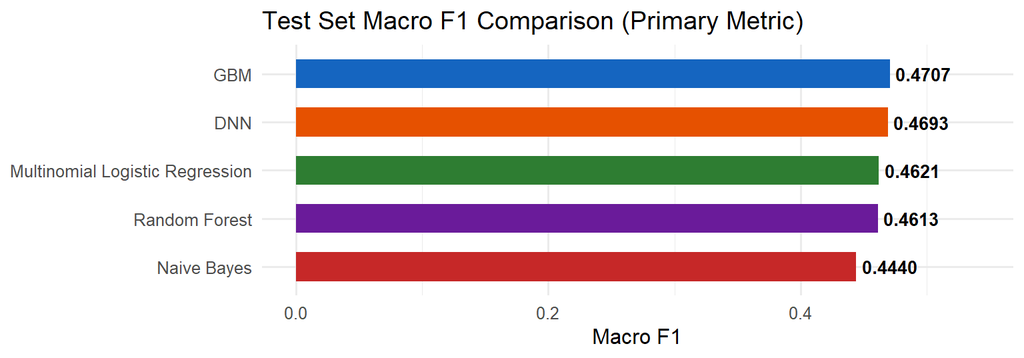

```r
ggplot(comparison, aes(x = reorder(Model, Macro_F1), y = Macro_F1, fill = Model)) +
  geom_col(width = 0.6) +
  geom_text(aes(label = sprintf("%.4f", Macro_F1)), hjust = -0.1, size = 3.5, fontface = "bold") +
  coord_flip() +
  scale_fill_manual(values = c("GBM"="#1565C0", "DNN"="#E65100",
    "Multinomial Logistic Regression"="#2E7D32", "Random Forest"="#6A1B9A", "Naive Bayes"="#C62828")) +
  labs(title = "Test Set Macro F1 Comparison (Primary Metric)", x = NULL, y = "Macro F1") +
  theme_minimal(base_size = 12) + theme(legend.position = "none") +
  ylim(0, max(comparison$Macro_F1) * 1.15)
```

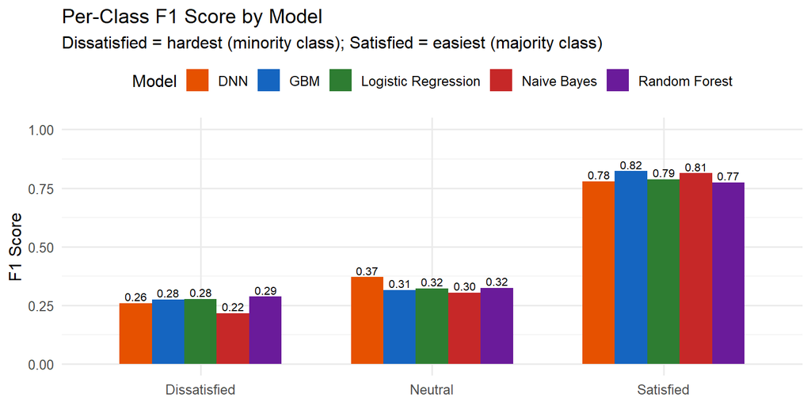

```r
all_class <- bind_rows(
  gbm_res$class_metrics %>% mutate(Model = "GBM"),
  dnn_res$class_metrics %>% mutate(Model = "DNN"),
  nb_res$class_metrics  %>% mutate(Model = "Naive Bayes"),
  rf_res$class_metrics  %>% mutate(Model = "Random Forest"),
  lr_res$class_metrics  %>% mutate(Model = "Logistic Regression"))

ggplot(all_class, aes(x = Class, y = F1, fill = Model)) +
  geom_col(position = "dodge", width = 0.7) +
  geom_text(aes(label = sprintf("%.2f", F1)),
            position = position_dodge(0.7), vjust = -0.3, size = 2.8) +
  scale_fill_manual(values = c("GBM"="#1565C0", "DNN"="#E65100",
    "Logistic Regression"="#2E7D32", "Random Forest"="#6A1B9A", "Naive Bayes"="#C62828")) +
  labs(title = "Per-Class F1 Score by Model",
       subtitle = "Dissatisfied = hardest (minority class); Satisfied = easiest (majority class)",
       x = NULL, y = "F1 Score") +
  theme_minimal(base_size = 12) + theme(legend.position = "top") + ylim(0, 1)
```

#### 7.2 Final Model Selection

Based on the evaluation, **Gradient Boosting (GBM)** is selected as the final model:

We found that the macro F1 scores of the five models were all between 0.44 and 0.47, which explains the phenomenon we observed in the PCA plot: the three classes have a high degree of overlap in the feature space, and the first two features have low explanatory power. It’s difficult for the model to learn a good classification boundary using only the features provided in the dataset. Despite our numerous optimization attempts, we observed little difference in performance between the simplest and most effective model (logistic regression, 0.4621) and the best model (GBM, 0.4707), indicating that the bottleneck lies in the lack of decisive features rather than model performance. For example, two people with similar features might have one choose neutral while the other chooses satisfied, posing a significant challenge to the model’s classification.

### 8 Final Results and Conclusions

#### 8.1 Optimal Model

The optimal model selected in this study was the three-class gradient boosting machine (GBM) model. This model was optimized through hierarchical three-fold cross-validation and used the macro F1 score as the main indicator, making it the most reliable among all trained models.

#### 8.2 Phenomenon Revealed

Based on the GBM model, the 15 most influential factors on job satisfaction under the three-class classification are shown in the figure below.

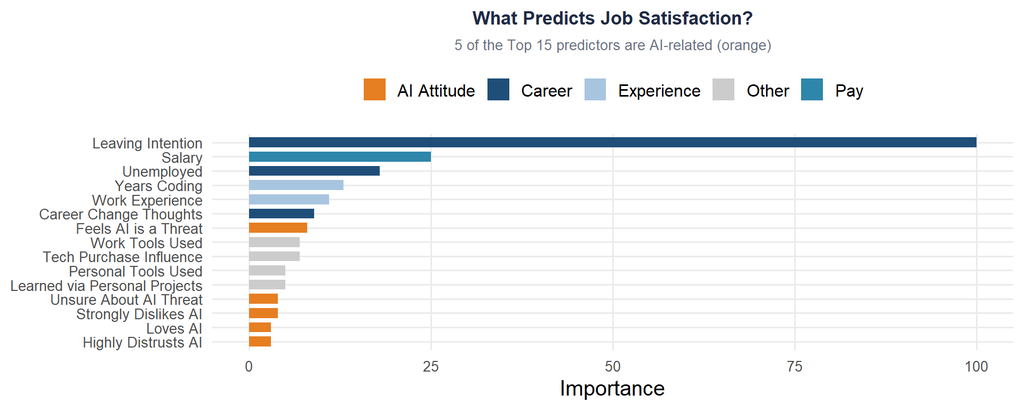

First, the strongest predictor is the LeavingScore, an ordinal feature extracted from the `NewRole` variable. It reflects the developer’s willingness to leave or change careers. According to the data, respondents with thoughts of changing careers are likely to have lower job satisfaction. Considering the causal relationship between the two, this phenomenon clearly conforms to common social perception.

Second, the impact of revealing factors on respondents’ job satisfaction is generally expected. Salary ranks second in influence, significantly affecting respondents’ living standards, and showing a strong correlation between salary level and job satisfaction. Employment status and years of work experience followed closely, reflecting that career stage and job stability influence people’s judgment to some extent.

##### 8.2.1 Latest Finding

Among the top 15 factors most significantly impacting job satisfaction, five are related to artificial intelligence. This has never occurred before 2025. This demonstrates that the existence of AI has already significantly impacted people’s work. Especially in the current software development field, understanding AI has become a crucial component in comprehending the developer’s work experience.

The following chart illustrates the different attitudes participants had towards artificial intelligence and their corresponding job satisfaction analysis results.

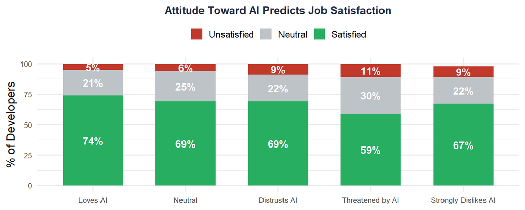

These data suggest that simple likes or dislikes have little impact on job satisfaction. However, those who perceive AI as a direct threat to their future career development and feel fear are more dissatisfied with their jobs.

#### 8.3 Conclusion

In summary, the results of this study indicate that by 2025, developer job satisfaction will depend not only on traditional factors, such as career stage and salary, but also on whether developers feel safe in a workplace increasingly influenced by artificial intelligence.

Secondly, artificial intelligence can now objectively influence workers’ job satisfaction. Furthermore, people’s subjective attitudes towards artificial intelligence are also correlated with their job satisfaction; those who feel their jobs are threatened by AI are more likely to be dissatisfied with their jobs than those who simply like or dislike AI.

### 9 References

Agresti, A. (2018). An introduction to categorical data analysis (3rd ed.). Wiley.

Breiman, L. (2001). Random forests. Machine Learning, 45(1), 5–32. https://doi.org/10.1023/A:1010933404324

Friedman, J. H. (2001). Greedy function approximation: A gradient boosting machine. The Annals of Statistics, 29(5), 1189–1232. https://doi.org/10.1214/aos/1013203451

Hand, D. J., & Yu, K. (2001). Idiot’s Bayes—not so stupid after all? International Statistical Review, 69(3), 385–398. https://doi.org/10.1111/j.1751-5823.2001.tb00465.x

LeCun, Y., Bengio, Y., & Hinton, G. (2015). Deep learning. Nature, 521(7553), 436–444. https://doi.org/10.1038/nature14539

Locke, E. A. (1976). The nature and causes of job satisfaction. In M. D. Dunnette (Ed.), Handbook of industrial and organizational psychology (pp. 1297–1349). Rand McNally.

Sokolova, M., & Lapalme, G. (2009). A systematic analysis of performance measures for classification tasks. Information Processing & Management, 45(4), 427–437. https://doi.org/10.1016/j.ipm.2009.03.002

Stack Overflow. (2025). Stack Overflow annual developer survey 2025 [Data set]. https://survey.stackoverflow.co/

### 10 AI Use Statement

AI was not used in completing this assignment.